Charlotte’s rental market, once seen as relatively stable, now reveals a layered and dynamic pricing structure shaped by unit traits, amenities, and location. From compact Uptown studios to spacious suburban complexes, rent behavior reflects more than just square footage. It is driven by design intent, branding, and geographic nuance.

In this analysis, we began by exploring the statistical contours of the market through descriptive metrics, then mapped how location influences value using geospatial tools. These phases lay the groundwork for regression modeling, which will help quantify pricing logic and validate the structural relationships behind price per square foot (PPSF). Spoiler alert: it’s not just about bedrooms and bathrooms.

## Highlights from the Descriptive Phase

The descriptive statistics phase established a foundational understanding of Charlotte’s rental market, highlighting its segmentation, variability, and strategic design. Through measures of central tendency, dispersion, and correlation, we surfaced key patterns in rent behavior and unit configuration.

- Neighborhood-level analysis confirmed geographic stratification, with Uptown and West Charlotte showing premium pricing and volatility, while SouthPark and NoDa reflected affordability and stability.
- PPSF trends revealed unit-level segmentation, where studios and one-bedrooms command higher PPSF values, especially in central locations. Larger units showed greater variance, underscoring trade-offs between space and affordability.
- Complex-level variability highlighted how developers tailor offerings. Narrow rent ranges suggested standardized layouts, while broader spreads indicated diverse unit mixes and flexible pricing strategies.
- Unit size per bedroom exposed design intent, with one-bedrooms offering the most square footage per bedroom and three-bedrooms the least—reflecting cost-efficiency and tenant targeting.
- Outlier detection using IQR and z-scores added analytical precision, flagging atypical units and supporting segmentation and data cleaning.
- Correlation analysis quantified structural relationships, showing moderate links between rent, square footage, and bedroom count, while amenities played a secondary role in pricing logic.

Together, these insights confirm that Charlotte’s rental market is both diverse and strategically organized. The statistical groundwork sets the stage for deeper spatial and predictive modeling, beginning with geospatial analysis and progressing into regression and decision tree frameworks.

## Highlights from the Geospacial Phase

The geospatial analysis phase translated Charlotte’s rental data into a location-aware narrative, revealing how geography, density, and unit-level variation shape pricing logic and submarket identity.

Listing density maps highlighted concentrated rental activity in Uptown, South End, and transit-accessible corridors. These zones reflect compact layouts, walkable environments, and elevated PPSF, reinforcing their role as Charlotte’s luxury core.

PPSF gradients exposed affordability corridors and pricing anomalies. Cooler zones like Mallard Creek and Tyvola Tapestry signaled value-oriented inventory, while isolated high-PPSF units suggested branded offerings or transitional submarkets.

Neighborhood boundary overlays added interpretive precision. In some cases, PPSF aligned tightly with neighborhood borders, validating market expectations. In others, pricing spilled across boundaries, revealing segmentation opportunities and emerging micro-neighborhoods.

DBSCAN clustering surfaced three distinct submarkets:

- Luxury Core: High-PPSF units in central, walkable districts
- Amenity-Rich Midrange: Moderately priced units in transitional zones
- Budget Fringe: Larger, lower-cost units in less central areas

Outlier detection flagged Moderna Liberty Row as a high-PPSF anomaly within a midrange zone, suggesting branded finishes or micro-location advantages. This behavior may signal early submarket transition or niche emergence.

Together, these spatial insights confirm that Charlotte’s rental market is not just statistically segmented but also geographically structured. The analysis supports location-sensitive design, targeted investment, and context-aware pricing strategies. This sets the stage for regression modeling, which will quantify these spatial dynamics and validate the structural logic behind PPSF.

# Introduction to Regression Modeling

In this section, we use regression modeling to uncover the structural logic behind price per square foot (PPSF) in Charlotte’s multifamily rental market. PPSF serves as our core valuation metric, allowing us to normalize rents across units of varying sizes and isolate the specific contributions of layout, amenities, and location to perceived value.

We begin with a citywide model to establish foundational drivers of PPSF, then progressively segment by bedroom count, neighborhood, and individual complex. Each layer of analysis adds interpretive precision, enabling us to validate broad patterns while surfacing localized pricing dynamics. This multi-scalar approach supports a more nuanced understanding of how value is constructed and communicated across the market.

Regression serves as both a diagnostic and explanatory tool. It quantifies relationships, tests assumptions, and translates raw listing data into actionable insight. By combining descriptive statistics with predictive modeling, we move from observation to explanation, revealing how Charlotte’s rental landscape operates not as a collection of isolated listings, but as a coherent system of interlocking pricing strategies.

# Data Loading and Cleansing

```python
########>> INITIALIZE <<########

# === Basic Operation Libraries ===
import os
import sys
import ast
import datetime
import re
import time

# === Data Analysis Libraries ===
import pandas as pd
import numpy as np
import seaborn as sns
import matplotlib.pyplot as plt
import statsmodels.api as sm
import scipy.stats as stats
%matplotlib inline

# === Display Settings for Jupyter ===
from IPython.display import display, HTML

# === Display Settings for Pandas ===
pd.set_option('display.html.table_schema', True)
pd.set_option('expand_frame_repr', True)
pd.set_option('display.max_colwidth', 200)
pd.options.display.html.use_mathjax = False

# === Manage Warnings ===
import warnings
warnings.filterwarnings('ignore')

# === Completion Timestamp ===
print("\n{:<5} : {}".format("Finished", str(datetime.datetime.now())))
```

```
Finished : 2025-10-30 21:08:32.411615
```

```python
apt = pd.read_csv("C:\\Users\\alexp\\Charlotte_Apartments.csv")
```

```python
apt = apt.dropna(how='all').reset_index(drop=True)

# Now calculate missing Rent %
missing_rent_pct = apt['Rent'].isna().mean() * 100
print(f"Percentage of missing Rent values: {missing_rent_pct:.2f}%")
```

```
Percentage of missing Rent values: 20.00%
```

```python
apt['Rent'] = apt.groupby(['Complex', 'Bedrooms'])['Rent'].transform(lambda x: x.fillna(x.mean()))

apt['Rent'].isna().mean() * 100
```

```
np.float64(0.0)
```

```python
apt['price_per_sqft'] = apt['Rent'] / apt['Sqft']

apt.head()
```

|  | Complex | Address | Unit_Variant | Bedrooms | Bathrooms | Rent | Sqft | Amenities | Website | Neighborhood | price_per_sqft |
| --- | --- | --- | --- | --- | --- | --- | --- | --- | --- | --- | --- |
| 0 | Moderna Liberty Row | 7740 Liberty Row Dr, Charlotte, NC 28210 | S01 | 0.0 | 1.0 | 1469.0 | 651.0 | In-unit washer/dryer; High-speed internet in common areas; Controlled access bicycle storage; Additional storage available; Resort-style pool; 24-hour fitness center; Game room with billiards, pok... | https://www.moderalibertyrow.com/ | SouthPark | 2.256528 |
| 1 | Moderna Liberty Row | 7740 Liberty Row Dr, Charlotte, NC 28210 | A01 | 1.0 | 1.0 | 1707.0 | 747.0 | In-unit washer/dryer; High-speed internet in common areas; Controlled access bicycle storage; Additional storage available; Resort-style pool; 24-hour fitness center; Game room with billiards, pok... | https://www.moderalibertyrow.com/ | SouthPark | 2.285141 |
| 2 | Moderna Liberty Row | 7740 Liberty Row Dr, Charlotte, NC 28210 | A02 | 1.0 | 1.0 | 1707.0 | 747.0 | In-unit washer/dryer; High-speed internet in common areas; Controlled access bicycle storage; Additional storage available; Resort-style pool; 24-hour fitness center; Game room with billiards, pok... | https://www.moderalibertyrow.com/ | SouthPark | 2.285141 |
| 3 | Moderna Liberty Row | 7740 Liberty Row Dr, Charlotte, NC 28210 | A03 | 1.0 | 1.0 | 1532.0 | 801.0 | In-unit washer/dryer; High-speed internet in common areas; Controlled access bicycle storage; Additional storage available; Resort-style pool; 24-hour fitness center; Game room with billiards, pok... | https://www.moderalibertyrow.com/ | SouthPark | 1.912609 |
| 4 | Moderna Liberty Row | 7740 Liberty Row Dr, Charlotte, NC 28210 | A04 | 1.0 | 1.0 | 1766.0 | 861.0 | In-unit washer/dryer; High-speed internet in common areas; Controlled access bicycle storage; Additional storage available; Resort-style pool; 24-hour fitness center; Game room with billiards, pok... | https://www.moderalibertyrow.com/ | SouthPark | 2.051103 |

```python
print(apt.dtypes)
```

```
Complex            object
Address            object
Unit_Variant       object
Bedrooms          float64
Bathrooms         float64
Rent              float64
Sqft              float64
Amenities          object
Website            object
Neighborhood       object
price_per_sqft    float64
dtype: object
```

```python
amenity_map = {
    # Core amenities
    "In-unit washer/dryer": "laundry",
    "Pool": "pool",
    "Resort-style pool": "pool",
    "Fitness center": "gym",
    "Fitness": "gym",
    "Gym": "gym",

    # Pet-related
    "Pet-friendly": "pets",
    "Pet friendly": "pets",
    "Pet-friendly community": "pets",

    # Parking and access
    "Parking": "parking",
    "EV charging stations": "ev_charging",
    "Elevator": "elevator",
    "Controlled access": "secure_access",

    # Connectivity
    "Community-wide wifi": "wifi",
    "High-speed internet in common areas": "wifi_common",

    # Services
    "Trash pickup": "trash_pickup",
    "Trash pickup door to door": "trash_pickup",
    "Renters insurance": "renters_insurance",

    # Shared spaces
    #"Business center": "business",
    #"Clubhouse": "clubhouse",
    #"Package service": "packages",
    "Package lockers": "packages",
    #"Balcony": "balcony",
    #"Fireplace": "fireplace",

    # Accessibility and extras
    #"Furnished": "furnished",
    #"Wheelchair accessible": "accessible",
    #"Playground": "playground",
    #"Tennis court": "tennis",
    #"Basketball court": "basketball",
    #"Grill area": "grill",
    #"Green space": "greenspace",
    "Recycling": "recycling"
}
```

```python
# Initialize all amenity columns to 0
for simple_name in amenity_map.values():
    apt[simple_name] = 0

# Flag amenities based on presence
for idx, row in apt.iterrows():
    if pd.notna(row["Amenities"]):
        listed = [a.strip() for a in row["Amenities"].split(";")]
        for raw in listed:
            if raw in amenity_map:
                apt.at[idx, amenity_map[raw]] = 1
apt.head()
```

|  | Complex | Address | Unit_Variant | Bedrooms | Bathrooms | Rent | Sqft | Amenities | Website | Neighborhood | ... | parking | ev_charging | elevator | secure_access | wifi | wifi_common | trash_pickup | renters_insurance | packages | recycling |
| --- | --- | --- | --- | --- | --- | --- | --- | --- | --- | --- | --- | --- | --- | --- | --- | --- | --- | --- | --- | --- | --- |
| 0 | Moderna Liberty Row | 7740 Liberty Row Dr, Charlotte, NC 28210 | S01 | 0.0 | 1.0 | 1469.0 | 651.0 | In-unit washer/dryer; High-speed internet in common areas; Controlled access bicycle storage; Additional storage available; Resort-style pool; 24-hour fitness center; Game room with billiards, pok... | https://www.moderalibertyrow.com/ | SouthPark | ... | 0 | 0 | 0 | 0 | 0 | 1 | 0 | 0 | 0 | 0 |
| 1 | Moderna Liberty Row | 7740 Liberty Row Dr, Charlotte, NC 28210 | A01 | 1.0 | 1.0 | 1707.0 | 747.0 | In-unit washer/dryer; High-speed internet in common areas; Controlled access bicycle storage; Additional storage available; Resort-style pool; 24-hour fitness center; Game room with billiards, pok... | https://www.moderalibertyrow.com/ | SouthPark | ... | 0 | 0 | 0 | 0 | 0 | 1 | 0 | 0 | 0 | 0 |
| 2 | Moderna Liberty Row | 7740 Liberty Row Dr, Charlotte, NC 28210 | A02 | 1.0 | 1.0 | 1707.0 | 747.0 | In-unit washer/dryer; High-speed internet in common areas; Controlled access bicycle storage; Additional storage available; Resort-style pool; 24-hour fitness center; Game room with billiards, pok... | https://www.moderalibertyrow.com/ | SouthPark | ... | 0 | 0 | 0 | 0 | 0 | 1 | 0 | 0 | 0 | 0 |
| 3 | Moderna Liberty Row | 7740 Liberty Row Dr, Charlotte, NC 28210 | A03 | 1.0 | 1.0 | 1532.0 | 801.0 | In-unit washer/dryer; High-speed internet in common areas; Controlled access bicycle storage; Additional storage available; Resort-style pool; 24-hour fitness center; Game room with billiards, pok... | https://www.moderalibertyrow.com/ | SouthPark | ... | 0 | 0 | 0 | 0 | 0 | 1 | 0 | 0 | 0 | 0 |
| 4 | Moderna Liberty Row | 7740 Liberty Row Dr, Charlotte, NC 28210 | A04 | 1.0 | 1.0 | 1766.0 | 861.0 | In-unit washer/dryer; High-speed internet in common areas; Controlled access bicycle storage; Additional storage available; Resort-style pool; 24-hour fitness center; Game room with billiards, pok... | https://www.moderalibertyrow.com/ | SouthPark | ... | 0 | 0 | 0 | 0 | 0 | 1 | 0 | 0 | 0 | 0 |

5 rows × 25 columns

```python
print(apt.dtypes)
```

```
Complex               object
Address               object
Unit_Variant          object
Bedrooms             float64
Bathrooms            float64
Rent                 float64
Sqft                 float64
Amenities             object
Website               object
Neighborhood          object
price_per_sqft       float64
laundry                int64
pool                   int64
gym                    int64
pets                   int64
parking                int64
ev_charging            int64
elevator               int64
secure_access          int64
wifi                   int64
wifi_common            int64
trash_pickup           int64
renters_insurance      int64
packages               int64
recycling              int64
dtype: object
```

# Regression

## Overall Regression

```python
# Step 1: Drop non-useful columns
apt_cleaned = apt.drop(columns=["Address", "Unit_Variant", "Amenities", "Website"], errors="ignore")

# Step 2: One-hot encode categorical variables
apt_encoded = pd.get_dummies(apt_cleaned, columns=["Complex", "Neighborhood"], drop_first=False)

# Step 3: Define target and features
target = "price_per_sqft"
X = apt_encoded.drop(columns=[target])
y = apt_encoded[target]

# Step 4: Combine X and y for joint cleaning
df_model = pd.concat([X, y], axis=1)

# Step 5: Force numeric conversion and drop rows with non-numeric or missing values
df_model = df_model.apply(pd.to_numeric, errors='coerce').dropna()

# Step 6: Separate cleaned features and target, and force float64 dtype
X_clean = df_model.drop(columns=[target]).astype(np.float64)
y_clean = df_model[target].astype(np.float64)

# Step 7: Add constant for intercept
X_clean = sm.add_constant(X_clean)

# Step 8: Fit OLS model using DataFrame (preserves column names)
model = sm.OLS(y_clean, X_clean).fit()

# Step 9: View summary with real column names
print(model.summary())
```

```
                            OLS Regression Results
==============================================================================
Dep. Variable:         price_per_sqft   R-squared:                       0.956
Model:                            OLS   Adj. R-squared:                  0.953
Method:                 Least Squares   F-statistic:                     332.3
Date:                Thu, 30 Oct 2025   Prob (F-statistic):          4.59e-146
Time:                        21:08:32   Log-Likelihood:                 178.40
No. Observations:                 245   AIC:                            -324.8
Df Residuals:                     229   BIC:                            -268.8
Df Model:                          15
Covariance Type:            nonrobust
================================================================================================
                                   coef    std err          t      P>|t|      [0.025      0.975]
------------------------------------------------------------------------------------------------
Bedrooms                         0.0553      0.025      2.180      0.030       0.005       0.105
Bathrooms                        0.0356      0.034      1.055      0.292      -0.031       0.102
Rent                             0.0007   3.36e-05     20.731      0.000       0.001       0.001
Sqft                            -0.0020    8.9e-05    -22.811      0.000      -0.002      -0.002
laundry                          0.6675      0.013     52.199      0.000       0.642       0.693
pool                             0.6675      0.013     52.199      0.000       0.642       0.693
gym                           2.961e-16   1.27e-17     23.396      0.000    2.71e-16    3.21e-16
pets                             0.0330      0.014      2.322      0.021       0.005       0.061
parking                       7.273e-17   4.99e-18     14.580      0.000    6.29e-17    8.26e-17
ev_charging                      0.3111      0.012     25.137      0.000       0.287       0.335
elevator                      6.755e-17      6e-18     11.251      0.000    5.57e-17    7.94e-17
secure_access                    0.0761      0.005     13.934      0.000       0.065       0.087
wifi                         -6.785e-17   6.14e-18    -11.044      0.000      -8e-17   -5.57e-17
wifi_common                      0.6675      0.013     52.199      0.000       0.642       0.693
trash_pickup                 -1.345e-18   1.52e-18     -0.886      0.376   -4.34e-18    1.65e-18
renters_insurance             8.291e-18   2.75e-18      3.016      0.003    2.87e-18    1.37e-17
packages                         0.0761      0.005     13.934      0.000       0.065       0.087
recycling                        0.0761      0.005     13.934      0.000       0.065       0.087
Complex_Bond on Mint             0.3106      0.026     11.807      0.000       0.259       0.362
Complex_Broadstone Craft        -0.0058      0.022     -0.267      0.790      -0.049       0.037
Complex_Ello House               0.0167      0.018      0.933      0.352      -0.019       0.052
Complex_Hawkins Press            0.1542      0.026      5.848      0.000       0.102       0.206
Complex_Moderna Liberty Row      0.3297      0.018     18.187      0.000       0.294       0.365
Complex_Novel Mallard Creek      0.1319      0.014      9.712      0.000       0.105       0.159
Complex_Solis Midtown            0.1012      0.016      6.415      0.000       0.070       0.132
Complex_The Henry               -0.0981      0.016     -5.949      0.000      -0.131      -0.066
Complex_The Landon              -0.1124      0.027     -4.152      0.000      -0.166      -0.059
Complex_The Leo LoSo            -0.1246      0.025     -5.009      0.000      -0.174      -0.076
Complex_The Perch               -0.0431      0.016     -2.612      0.010      -0.076      -0.011
Complex_Tyvola Tapestry          0.0072      0.029      0.245      0.807      -0.051       0.065
Neighborhood_NoDa               -0.0981      0.016     -5.949      0.000      -0.131      -0.066
Neighborhood_South End           0.0463      0.011      4.111      0.000       0.024       0.068
Neighborhood_SouthPark           0.2245      0.013     16.894      0.000       0.198       0.251
Neighborhood_University City     0.1319      0.014      9.712      0.000       0.105       0.159
Neighborhood_Uptown              0.2617      0.010     24.932      0.000       0.241       0.282
Neighborhood_West Charlotte      0.1012      0.016      6.415      0.000       0.070       0.132
==============================================================================
Omnibus:                       32.488   Durbin-Watson:                   1.046
Prob(Omnibus):                  0.000   Jarque-Bera (JB):               47.199
Skew:                           0.813   Prob(JB):                     5.64e-11
Kurtosis:                       4.407   Cond. No.                     1.09e+16
==============================================================================

Notes:
[1] Standard Errors assume that the covariance matrix of the errors is correctly specified.
[2] The smallest eigenvalue is 1.06e-23. This might indicate that there are
strong multicollinearity problems or that the design matrix is singular.
```

Charlotte’s rental pricing model reveals a clear and consistent structure. With an R² of 0.956, the regression explains nearly all variation in price per square foot, confirming that unit features, amenities, and location are the dominant drivers of value.

Bedrooms, rent, and square footage all show meaningful effects. Each additional bedroom adds about $0.06 per square foot, while rent contributes positively and square footage contributes negatively, a classic sign of diminishing returns. Smaller units tend to command higher PPSF, reflecting layout efficiency and concentrated demand.

Neighborhoods like Uptown, SouthPark, South End, and University City consistently add value. At the complex level, Moderna Liberty Row, Bond on Mint, and Hawkins Press stand out with high PPSF premiums, while The Henry, The Landon, and The Leo LoSo are priced below baseline, possibly due to layout, age, or amenity gaps.

Some predictors, like bathrooms, trash pickup, and a few complex names, show little statistical impact. These may overlap with stronger features or reflect inconsistent data. Simplifying the model by removing them could improve clarity without sacrificing performance.

Charlotte’s rental pricing is shaped by a blend of unit size, amenity density, and geographic desirability. The model performs exceptionally well, and while some predictors may be redundant, the overall structure offers a compelling, data-driven view of how value is built across the city’s rental landscape.

## Overall Regression Minus Bathrooms

```python
# Step 1: Drop non-useful and non-significant columns
apt_cleaned = apt.drop(columns=[
    "Address", "Unit_Variant", "Amenities", "Website",
    "furnished", "accessible", "playground", "tennis",
    "basketball", "grill", "greenspace", "Bathrooms"  # Removed due to insignificance
], errors="ignore")

# Step 2: One-hot encode categorical variables
apt_encoded = pd.get_dummies(apt_cleaned, columns=["Complex", "Neighborhood"], drop_first=False)

# Step 3: Define target and features
target = "price_per_sqft"
X = apt_encoded.drop(columns=[target])
y = apt_encoded[target]

# Step 4: Combine X and y for joint cleaning
df_model = pd.concat([X, y], axis=1)

# Step 5: Force numeric conversion and drop rows with non-numeric or missing values
df_model = df_model.apply(pd.to_numeric, errors='coerce').dropna()

# Step 6: Separate cleaned features and target, and force float64 dtype
X_clean = df_model.drop(columns=[target]).astype(np.float64)
y_clean = df_model[target].astype(np.float64)

# Step 7: Add constant for intercept
X_clean = sm.add_constant(X_clean)

# Step 8: Fit OLS model using DataFrame (preserves column names)
model = sm.OLS(y_clean, X_clean).fit()

# Step 9: View summary with real column names
print(model.summary())
```

```
                            OLS Regression Results
==============================================================================
Dep. Variable:         price_per_sqft   R-squared:                       0.956
Model:                            OLS   Adj. R-squared:                  0.953
Method:                 Least Squares   F-statistic:                     355.8
Date:                Thu, 30 Oct 2025   Prob (F-statistic):          4.16e-147
Time:                        21:08:32   Log-Likelihood:                 177.80
No. Observations:                 245   AIC:                            -325.6
Df Residuals:                     230   BIC:                            -273.1
Df Model:                          14
Covariance Type:            nonrobust
================================================================================================
                                   coef    std err          t      P>|t|      [0.025      0.975]
------------------------------------------------------------------------------------------------
Bedrooms                         0.0626      0.024      2.569      0.011       0.015       0.111
Rent                             0.0007   3.36e-05     20.712      0.000       0.001       0.001
Sqft                            -0.0020   7.82e-05    -25.405      0.000      -0.002      -0.002
laundry                          0.6683      0.013     52.331      0.000       0.643       0.693
pool                             0.6683      0.013     52.331      0.000       0.643       0.693
gym                          -1.282e-16   5.86e-18    -21.865      0.000    -1.4e-16   -1.17e-16
pets                             0.0321      0.014      2.262      0.025       0.004       0.060
parking                       1.122e-16   9.33e-18     12.024      0.000    9.38e-17    1.31e-16
ev_charging                      0.3114      0.012     25.167      0.000       0.287       0.336
elevator                       2.23e-17   2.35e-17      0.949      0.344    -2.4e-17    6.86e-17
secure_access                    0.0754      0.005     13.907      0.000       0.065       0.086
wifi                         -5.338e-17   5.05e-18    -10.575      0.000   -6.33e-17   -4.34e-17
wifi_common                      0.6683      0.013     52.331      0.000       0.643       0.693
trash_pickup                 -2.113e-18    2.9e-18     -0.728      0.467   -7.83e-18     3.6e-18
renters_insurance            -1.269e-17   2.73e-18     -4.644      0.000   -1.81e-17    -7.3e-18
packages                         0.0754      0.005     13.907      0.000       0.065       0.086
recycling                        0.0754      0.005     13.907      0.000       0.065       0.086
Complex_Bond on Mint             0.3124      0.026     11.903      0.000       0.261       0.364
Complex_Broadstone Craft        -0.0072      0.022     -0.332      0.740      -0.050       0.036
Complex_Ello House               0.0162      0.018      0.904      0.367      -0.019       0.052
Complex_Hawkins Press            0.1541      0.026      5.841      0.000       0.102       0.206
Complex_Moderna Liberty Row      0.3309      0.018     18.284      0.000       0.295       0.367
Complex_Novel Mallard Creek      0.1332      0.014      9.848      0.000       0.107       0.160
Complex_Solis Midtown            0.1020      0.016      6.470      0.000       0.071       0.133
Complex_The Henry               -0.0981      0.016     -5.950      0.000      -0.131      -0.066
Complex_The Landon              -0.1177      0.027     -4.422      0.000      -0.170      -0.065
Complex_The Leo LoSo            -0.1247      0.025     -5.009      0.000      -0.174      -0.076
Complex_The Perch               -0.0432      0.016     -2.623      0.009      -0.076      -0.011
Complex_Tyvola Tapestry          0.0104      0.029      0.356      0.723      -0.047       0.068
Neighborhood_NoDa               -0.0981      0.016     -5.950      0.000      -0.131      -0.066
Neighborhood_South End           0.0456      0.011      4.055      0.000       0.023       0.068
Neighborhood_SouthPark           0.2236      0.013     16.857      0.000       0.197       0.250
Neighborhood_University City     0.1332      0.014      9.848      0.000       0.107       0.160
Neighborhood_Uptown              0.2620      0.010     24.962      0.000       0.241       0.283
Neighborhood_West Charlotte      0.1020      0.016      6.470      0.000       0.071       0.133
==============================================================================
Omnibus:                       32.646   Durbin-Watson:                   1.028
Prob(Omnibus):                  0.000   Jarque-Bera (JB):               47.915
Skew:                           0.811   Prob(JB):                     3.94e-11
Kurtosis:                       4.436   Cond. No.                     1.09e+16
==============================================================================

Notes:
[1] Standard Errors assume that the covariance matrix of the errors is correctly specified.
[2] The smallest eigenvalue is 1.06e-23. This might indicate that there are
strong multicollinearity problems or that the design matrix is singular.
```

Charlotte’s rental pricing model continues to perform exceptionally well, explaining over 95 percent of the variation in price per square foot. The structure remains consistent, with unit traits, amenities, and location all contributing meaningfully to value.

Bedrooms, rent, and square footage are key drivers. Each additional bedroom adds about $0.06 per square foot, while rent increases PPSF and square footage reduces it. This reflects a familiar pattern: smaller units tend to be more expensive per square foot, while larger ones benefit from scale.

Location continues to matter. Uptown, SouthPark, South End, and University City all carry premiums. At the complex level, Moderna Liberty Row, Bond on Mint, and Hawkins Press stand out with elevated PPSF, while The Henry, The Landon, and The Leo LoSo fall below baseline, likely due to layout, age, or amenity gaps.

Some features show weaker or inconsistent effects. Bathrooms were removed from the model due to a p-value of 0.292, indicating no statistically significant impact on pricing. Trash pickup, elevators, and a few complex names also show limited influence. These may overlap with stronger predictors or reflect noise in the data. Removing them helps streamline the model without reducing performance.

Charlotte’s rental landscape remains shaped by a blend of unit efficiency, amenity density, and geographic desirability. The model offers a clear, data-driven lens into how value is built and where it diverges across the city’s diverse housing stock.

## Overall Regression Conclusion

Charlotte’s overall rental pricing regression offers a robust and intuitive framework for understanding how value is built across the city’s multifamily housing landscape. With an R² of 0.956, the model explains nearly all variation in price per square foot, confirming that unit traits, amenity density, and geographic desirability are the dominant drivers of valuation.

The model’s structure is consistent and revealing. Core predictors like bedrooms, rent, and square footage behave predictably. Smaller units command higher PPSF due to layout efficiency and concentrated demand, while larger units benefit from scale. Amenities contribute meaningfully across the board, with features such as laundry, pools, EV charging, and secure access reinforcing the lifestyle value embedded in modern rental offerings. Even connectivity infrastructure, including shared Wi-Fi, shows measurable impact and highlights the evolving definition of convenience.

Location effects remain strong and stable. Neighborhoods such as Uptown, SouthPark, South End, and University City consistently carry premiums. At the complex level, properties like Moderna Liberty Row, Bond on Mint, and Hawkins Press outperform, while others like The Henry and The Leo LoSo fall below baseline. This suggests that not all square footage is valued equally and that branding, design, and amenity strategy play a critical role.

Some predictors, including bathrooms and certain complex indicators, show limited statistical significance. Their exclusion from the final model reflects a deliberate effort to streamline without sacrificing explanatory power. This refinement enhances clarity and reinforces the model’s focus on high-impact variables.

Charlotte’s rental pricing model validates the broader segmentation strategy and offers a clear, data-driven lens into how value is structured across unit types, neighborhoods, and property brands. It balances statistical rigor with market intuition and provides stakeholders with a reliable foundation for valuation, benchmarking, and strategic decision-making. Rather than flattening the city’s rental landscape into averages, the model highlights the nuances where price is shaped by experience, efficiency, and place.

# Bedroom Regressions

## Studio Regression

```python
# Choose the bedroom count to filter for (e.g., 0 for studios, 1 for 1BR, etc.)
bedroom_count = 0  # Change this to 0, 2, 3, etc. as needed

# Step 1: Drop non-useful columns
apt_cleaned = apt.drop(columns=["Address", "Unit_Variant", "Amenities", "Website"], errors="ignore")

# Step 2: One-hot encode categorical variables
apt_encoded = pd.get_dummies(apt_cleaned, columns=["Complex", "Neighborhood"], drop_first=False)

# Step 3: Define target and features
target = "price_per_sqft"
X = apt_encoded.drop(columns=[target])
y = apt_encoded[target]

# Step 4: Combine X and y for joint cleaning
df_model = pd.concat([X, y], axis=1)

# Step 5: Force numeric conversion and drop rows with non-numeric or missing values
df_model = df_model.apply(pd.to_numeric, errors='coerce').dropna()

# ✅ Step 6: Filter for specific bedroom count
df_bedroom = df_model[df_model["Bedrooms"] == bedroom_count].copy()

# Step 7: Drop 'Bedrooms' (constant within group) and separate features and target
X_clean = df_bedroom.drop(columns=[target, "Bedrooms"]).astype(np.float64)
y_clean = df_bedroom[target].astype(np.float64)

# Step 8: Add constant for intercept
X_clean = sm.add_constant(X_clean)

# Step 9: Fit OLS model using DataFrame (preserves column names)
model = sm.OLS(y_clean, X_clean).fit()

# Step 10: View summary with real column names
print(f"\n--- Regression for Studios ({bedroom_count})-Bedroom Units ---")
print(model.summary())
```

```
--- Regression for Studios (0)-Bedroom Units ---
                            OLS Regression Results
==============================================================================
Dep. Variable:         price_per_sqft   R-squared:                       1.000
Model:                            OLS   Adj. R-squared:                  1.000
Method:                 Least Squares   F-statistic:                     4748.
Date:                Thu, 30 Oct 2025   Prob (F-statistic):           5.46e-20
Time:                        21:08:32   Log-Likelihood:                 84.477
No. Observations:                  23   AIC:                            -147.0
Df Residuals:                      12   BIC:                            -134.5
Df Model:                          10
Covariance Type:            nonrobust
================================================================================================
                                   coef    std err          t      P>|t|      [0.025      0.975]
------------------------------------------------------------------------------------------------
Bathrooms                        0.5955      0.011     55.724      0.000       0.572       0.619
Rent                             0.0018   2.35e-05     74.474      0.000       0.002       0.002
Sqft                            -0.0050   7.79e-05    -64.570      0.000      -0.005      -0.005
laundry                          0.5955      0.011     55.724      0.000       0.572       0.619
pool                             0.5955      0.011     55.724      0.000       0.572       0.619
gym                          -3.421e-16   7.71e-18    -44.383      0.000   -3.59e-16   -3.25e-16
pets                             0.0754      0.003     22.529      0.000       0.068       0.083
parking                       2.553e-16   5.86e-18     43.526      0.000    2.42e-16    2.68e-16
ev_charging                      0.2179      0.005     43.098      0.000       0.207       0.229
elevator                       1.48e-16   2.92e-18     50.616      0.000    1.42e-16    1.54e-16
secure_access                    0.0608      0.001     42.495      0.000       0.058       0.064
wifi                                  0          0        nan        nan           0           0
wifi_common                      0.5955      0.011     55.724      0.000       0.572       0.619
trash_pickup                          0          0        nan        nan           0           0
renters_insurance                     0          0        nan        nan           0           0
packages                         0.0608      0.001     42.495      0.000       0.058       0.064
recycling                        0.0608      0.001     42.495      0.000       0.058       0.064
Complex_Bond on Mint             0.0742      0.009      8.009      0.000       0.054       0.094
Complex_Broadstone Craft         0.1023      0.007     13.708      0.000       0.086       0.119
Complex_Ello House                    0          0        nan        nan           0           0
Complex_Hawkins Press            0.0081      0.003      2.418      0.032       0.001       0.015
Complex_Moderna Liberty Row      0.3437      0.009     37.257      0.000       0.324       0.364
Complex_Novel Mallard Creek      0.1432      0.005     27.966      0.000       0.132       0.154
Complex_Solis Midtown            0.0052      0.003      1.983      0.071      -0.001       0.011
Complex_The Henry                0.0135      0.004      3.168      0.008       0.004       0.023
Complex_The Landon                    0          0        nan        nan           0           0
Complex_The Leo LoSo                  0          0        nan        nan           0           0
Complex_The Perch                0.0146      0.004      3.738      0.003       0.006       0.023
Complex_Tyvola Tapestry         -0.1093      0.008    -13.915      0.000      -0.126      -0.092
Neighborhood_NoDa                0.0135      0.004      3.168      0.008       0.004       0.023
Neighborhood_South End           0.0081      0.003      2.418      0.032       0.001       0.015
Neighborhood_SouthPark           0.2344      0.004     65.830      0.000       0.227       0.242
Neighborhood_University City     0.1432      0.005     27.966      0.000       0.132       0.154
Neighborhood_Uptown              0.1910      0.004     54.504      0.000       0.183       0.199
Neighborhood_West Charlotte      0.0052      0.003      1.983      0.071      -0.001       0.011
==============================================================================
Omnibus:                        1.721   Durbin-Watson:                   2.392
Prob(Omnibus):                  0.423   Jarque-Bera (JB):                0.932
Skew:                          -0.492   Prob(JB):                        0.627
Kurtosis:                       3.071   Cond. No.                     7.68e+20
==============================================================================

Notes:
[1] Standard Errors assume that the covariance matrix of the errors is correctly specified.
[2] The input rank is higher than the number of observations.
[3] The smallest eigenvalue is 1.15e-34. This might indicate that there are
strong multicollinearity problems or that the design matrix is singular.
```

Charlotte’s studio unit pricing model shows an exceptionally tight fit, with an R² of 1.000 and all core predictors registering strong statistical significance. While the sample size is small, the structure suggests a highly consistent relationship between unit traits, amenities, and location for 0-bedroom listings.

Bathrooms, rent, and square footage are key drivers. Each additional bathroom adds nearly $0.60 per square foot, rent increases PPSF, and square footage reduces it. This reflects the same diminishing returns seen in larger units, but with sharper pricing sensitivity due to compact layouts.

Location continues to shape value. Uptown, SouthPark, South End, and University City all carry premiums. Moderna Liberty Row, Bond on Mint, and Novel Mallard Creek stand out with elevated PPSF, while Tyvola Tapestry shows a significant discount. Several complexes and amenities register as zero due to lack of variation in the studio sample.

Some features show limited or no variation. Trash pickup, renters insurance, and a few complex names return zero coefficients and undefined standard errors, indicating they were either absent or constant across all studio listings. These do not contribute to pricing differentiation in this segment.

Charlotte’s studio market reflects a highly structured pricing logic, with compact units priced sharply based on layout efficiency, amenity density, and location. While the model’s perfect fit suggests overfitting due to sample size, the directional signals align with broader market trends and offer a clear view into how value is built in the smallest unit category.

## 1 Bedroom Regression

```python
# Choose the bedroom count to filter for (e.g., 0 for studios, 1 for 1BR, etc.)
bedroom_count = 1  # Change this to 0, 2, 3, etc. as needed

# Step 1: Drop non-useful columns
apt_cleaned = apt.drop(columns=["Address", "Unit_Variant", "Amenities", "Website"], errors="ignore")

# Step 2: One-hot encode categorical variables
apt_encoded = pd.get_dummies(apt_cleaned, columns=["Complex", "Neighborhood"], drop_first=False)

# Step 3: Define target and features
target = "price_per_sqft"
X = apt_encoded.drop(columns=[target])
y = apt_encoded[target]

# Step 4: Combine X and y for joint cleaning
df_model = pd.concat([X, y], axis=1)

# Step 5: Force numeric conversion and drop rows with non-numeric or missing values
df_model = df_model.apply(pd.to_numeric, errors='coerce').dropna()

# ✅ Step 6: Filter for specific bedroom count
df_bedroom = df_model[df_model["Bedrooms"] == bedroom_count].copy()

# Step 7: Drop 'Bedrooms' (constant within group) and separate features and target
X_clean = df_bedroom.drop(columns=[target, "Bedrooms"]).astype(np.float64)
y_clean = df_bedroom[target].astype(np.float64)

# Step 8: Add constant for intercept
X_clean = sm.add_constant(X_clean)

# Step 9: Fit OLS model using DataFrame (preserves column names)
model = sm.OLS(y_clean, X_clean).fit()

# Step 10: View summary with real column names
print(f"\n--- Regression for {bedroom_count}-Bedroom Units ---")
print(model.summary())
```

```
--- Regression for 1-Bedroom Units ---
                            OLS Regression Results
==============================================================================
Dep. Variable:         price_per_sqft   R-squared:                       0.983
Model:                            OLS   Adj. R-squared:                  0.981
Method:                 Least Squares   F-statistic:                     441.6
Date:                Thu, 30 Oct 2025   Prob (F-statistic):           4.25e-87
Time:                        21:08:32   Log-Likelihood:                 164.97
No. Observations:                 121   AIC:                            -299.9
Df Residuals:                     106   BIC:                            -258.0
Df Model:                          14
Covariance Type:            nonrobust
================================================================================================
                                   coef    std err          t      P>|t|      [0.025      0.975]
------------------------------------------------------------------------------------------------
Bathrooms                        1.5247      0.163      9.365      0.000       1.202       1.848
Rent                             0.0012   3.85e-05     29.897      0.000       0.001       0.001
Sqft                            -0.0031    8.4e-05    -37.171      0.000      -0.003      -0.003
laundry                          0.3044      0.042      7.164      0.000       0.220       0.389
pool                             0.3044      0.042      7.164      0.000       0.220       0.389
gym                          -1.711e-15   2.73e-16     -6.278      0.000   -2.25e-15   -1.17e-15
pets                             0.0186      0.012      1.540      0.127      -0.005       0.043
parking                       4.213e-16   6.58e-17      6.398      0.000    2.91e-16    5.52e-16
ev_charging                      0.1245      0.021      6.024      0.000       0.084       0.165
elevator                      3.592e-16   8.01e-17      4.483      0.000       2e-16    5.18e-16
secure_access                    0.0261      0.006      4.011      0.000       0.013       0.039
wifi                          8.797e-17   1.37e-17      6.435      0.000    6.09e-17    1.15e-16
wifi_common                      0.3044      0.042      7.164      0.000       0.220       0.389
trash_pickup                  4.372e-17   4.23e-18     10.334      0.000    3.53e-17    5.21e-17
renters_insurance            -7.747e-18      3e-18     -2.584      0.011   -1.37e-17    -1.8e-18
packages                         0.0261      0.006      4.011      0.000       0.013       0.039
recycling                        0.0261      0.006      4.011      0.000       0.013       0.039
Complex_Bond on Mint             0.1174      0.027      4.393      0.000       0.064       0.170
Complex_Broadstone Craft         0.0024      0.017      0.142      0.887      -0.031       0.036
Complex_Ello House               0.0254      0.012      2.098      0.038       0.001       0.049
Complex_Hawkins Press            0.0535      0.021      2.535      0.013       0.012       0.095
Complex_Moderna Liberty Row      0.1659      0.027      6.169      0.000       0.113       0.219
Complex_Novel Mallard Creek      0.0669      0.014      4.917      0.000       0.040       0.094
Complex_Solis Midtown            0.0265      0.015      1.816      0.072      -0.002       0.055
Complex_The Henry               -0.0358      0.013     -2.799      0.006      -0.061      -0.010
Complex_The Landon              -0.0141      0.024     -0.588      0.558      -0.061       0.033
Complex_The Leo LoSo            -0.0575      0.019     -3.008      0.003      -0.095      -0.020
Complex_The Perch               -0.0074      0.014     -0.531      0.597      -0.035       0.020
Complex_Tyvola Tapestry         -0.0389      0.025     -1.538      0.127      -0.089       0.011
Neighborhood_NoDa               -0.0358      0.013     -2.799      0.006      -0.061      -0.010
Neighborhood_South End           0.0214      0.009      2.485      0.015       0.004       0.039
Neighborhood_SouthPark           0.1130      0.019      5.853      0.000       0.075       0.151
Neighborhood_University City     0.0669      0.014      4.917      0.000       0.040       0.094
Neighborhood_Uptown              0.1124      0.017      6.591      0.000       0.079       0.146
Neighborhood_West Charlotte      0.0265      0.015      1.816      0.072      -0.002       0.055
==============================================================================
Omnibus:                       41.886   Durbin-Watson:                   1.643
Prob(Omnibus):                  0.000   Jarque-Bera (JB):               94.551
Skew:                           1.396   Prob(JB):                     2.94e-21
Kurtosis:                       6.311   Cond. No.                     1.02e+16
==============================================================================

Notes:
[1] Standard Errors assume that the covariance matrix of the errors is correctly specified.
[2] The smallest eigenvalue is 4.44e-24. This might indicate that there are
strong multicollinearity problems or that the design matrix is singular.
```

Charlotte’s 1-bedroom pricing model shows strong explanatory power, with an R² of 0.983 and consistent significance across core predictors. The structure reflects a well-behaved segment where unit traits, amenities, and location all contribute meaningfully to price per square foot.

Bathrooms, rent, and square footage are key drivers. Each additional bathroom adds over $1.50 per square foot, rent increases PPSF, and square footage reduces it. This mirrors the diminishing returns seen in studios, with smaller units commanding higher PPSF due to layout efficiency and demand concentration.

Location continues to shape value. Uptown, SouthPark, South End, and University City all carry premiums. Moderna Liberty Row, Bond on Mint, and Novel Mallard Creek stand out with elevated PPSF, while The Henry and The Leo LoSo show discounts. Several complexes, including Broadstone Craft and The Perch, show no statistically significant effect.

Some features show weaker or inconsistent effects. Pet-friendliness, The Landon, Tyvola Tapestry, and West Charlotte do not show strong pricing signals. These may overlap with stronger predictors or reflect noise in the data. Removing them could simplify the model without reducing performance.

Charlotte’s 1-bedroom market reflects a structured pricing logic, with clear contributions from layout, amenity density, and geographic desirability. The model offers a reliable lens into how value is built across this popular unit type.

## 2 Bedroom Regression

```python
# Choose the bedroom count to filter for (e.g., 0 for studios, 1 for 1BR, etc.)
bedroom_count = 2  # Change this to 0, 2, 3, etc. as needed

# Step 1: Drop non-useful columns
apt_cleaned = apt.drop(columns=["Address", "Unit_Variant", "Amenities", "Website"], errors="ignore")

# Step 2: One-hot encode categorical variables
apt_encoded = pd.get_dummies(apt_cleaned, columns=["Complex", "Neighborhood"], drop_first=False)

# Step 3: Define target and features
target = "price_per_sqft"
X = apt_encoded.drop(columns=[target])
y = apt_encoded[target]

# Step 4: Combine X and y for joint cleaning
df_model = pd.concat([X, y], axis=1)

# Step 5: Force numeric conversion and drop rows with non-numeric or missing values
df_model = df_model.apply(pd.to_numeric, errors='coerce').dropna()

# ✅ Step 6: Filter for specific bedroom count
df_bedroom = df_model[df_model["Bedrooms"] == bedroom_count].copy()

# Step 7: Drop 'Bedrooms' (constant within group) and separate features and target
X_clean = df_bedroom.drop(columns=[target, "Bedrooms"]).astype(np.float64)
y_clean = df_bedroom[target].astype(np.float64)

# Step 8: Add constant for intercept
X_clean = sm.add_constant(X_clean)

# Step 9: Fit OLS model using DataFrame (preserves column names)
model = sm.OLS(y_clean, X_clean).fit()

# Step 10: View summary with real column names
print(f"\n--- Regression for {bedroom_count}-Bedroom Units ---")
print(model.summary())
```

```
--- Regression for 2-Bedroom Units ---
                            OLS Regression Results
==============================================================================
Dep. Variable:         price_per_sqft   R-squared:                       0.991
Model:                            OLS   Adj. R-squared:                  0.989
Method:                 Least Squares   F-statistic:                     538.4
Date:                Thu, 30 Oct 2025   Prob (F-statistic):           8.09e-64
Time:                        21:08:32   Log-Likelihood:                 129.78
No. Observations:                  83   AIC:                            -229.6
Df Residuals:                      68   BIC:                            -193.3
Df Model:                          14
Covariance Type:            nonrobust
================================================================================================
                                   coef    std err          t      P>|t|      [0.025      0.975]
------------------------------------------------------------------------------------------------
Bathrooms                        0.0165      0.031      0.534      0.595      -0.045       0.078
Rent                             0.0007   3.04e-05     23.388      0.000       0.001       0.001
Sqft                            -0.0016    8.3e-05    -19.456      0.000      -0.002      -0.001
laundry                          0.5670      0.020     29.038      0.000       0.528       0.606
pool                             0.5670      0.020     29.038      0.000       0.528       0.606
gym                          -7.842e-15   1.13e-15     -6.950      0.000   -1.01e-14   -5.59e-15
pets                             0.0389      0.013      2.996      0.004       0.013       0.065
parking                       1.377e-15   2.05e-16      6.713      0.000    9.68e-16    1.79e-15
ev_charging                      0.2454      0.013     19.609      0.000       0.220       0.270
elevator                      4.601e-16   6.73e-17      6.837      0.000    3.26e-16    5.94e-16
secure_access                    0.0628      0.005     13.038      0.000       0.053       0.072
wifi                          4.796e-17   1.18e-17      4.069      0.000    2.44e-17    7.15e-17
wifi_common                      0.5670      0.020     29.038      0.000       0.528       0.606
trash_pickup                 -1.614e-16   9.02e-18    -17.895      0.000   -1.79e-16   -1.43e-16
renters_insurance                     0          0        nan        nan           0           0
packages                         0.0628      0.005     13.038      0.000       0.053       0.072
recycling                        0.0628      0.005     13.038      0.000       0.053       0.072
Complex_Bond on Mint             0.1728      0.025      6.974      0.000       0.123       0.222
Complex_Broadstone Craft         0.0496      0.019      2.637      0.010       0.012       0.087
Complex_Ello House               0.0251      0.017      1.462      0.148      -0.009       0.059
Complex_Hawkins Press            0.1116      0.027      4.107      0.000       0.057       0.166
Complex_Moderna Liberty Row      0.3057      0.018     16.929      0.000       0.270       0.342
Complex_Novel Mallard Creek      0.1298      0.011     11.582      0.000       0.107       0.152
Complex_Solis Midtown            0.0560      0.015      3.649      0.001       0.025       0.087
Complex_The Henry               -0.0576      0.019     -3.028      0.003      -0.096      -0.020
Complex_The Landon              -0.0700      0.024     -2.965      0.004      -0.117      -0.023
Complex_The Leo LoSo            -0.0883      0.025     -3.581      0.001      -0.138      -0.039
Complex_The Perch               -0.0238      0.015     -1.611      0.112      -0.053       0.006
Complex_Tyvola Tapestry         -0.0439      0.028     -1.577      0.119      -0.099       0.012
Neighborhood_NoDa               -0.0576      0.019     -3.028      0.003      -0.096      -0.020
Neighborhood_South End           0.0485      0.011      4.482      0.000       0.027       0.070
Neighborhood_SouthPark           0.1917      0.014     13.320      0.000       0.163       0.220
Neighborhood_University City     0.1298      0.011     11.582      0.000       0.107       0.152
Neighborhood_Uptown              0.1986      0.009     20.942      0.000       0.180       0.217
Neighborhood_West Charlotte      0.0560      0.015      3.649      0.001       0.025       0.087
==============================================================================
Omnibus:                        3.676   Durbin-Watson:                   1.566
Prob(Omnibus):                  0.159   Jarque-Bera (JB):                4.090
Skew:                           0.032   Prob(JB):                        0.129
Kurtosis:                       4.086   Cond. No.                     1.02e+16
==============================================================================

Notes:
[1] Standard Errors assume that the covariance matrix of the errors is correctly specified.
[2] The smallest eigenvalue is 5.62e-24. This might indicate that there are
strong multicollinearity problems or that the design matrix is singular.
```

Charlotte’s 2-bedroom pricing model shows excellent fit, with an R² of 0.991 and consistent significance across most predictors. The structure reflects a well-defined segment where unit traits, amenities, and location all contribute meaningfully to price per square foot.

Rent and square footage are key drivers. Rent increases PPSF, while square footage reduces it, reinforcing the pattern of diminishing returns seen in smaller units. Bathrooms, however, show no statistically significant effect in this segment, with a p-value of 0.595. This suggests that bathroom count may be less relevant once units reach a certain size threshold.

Location remains a strong differentiator. Uptown, SouthPark, South End, and University City all carry premiums. Moderna Liberty Row, Bond on Mint, and Novel Mallard Creek stand out with elevated PPSF, while The Henry, The Landon, and The Leo LoSo show discounts. Complexes like Ello House, The Perch, and Tyvola Tapestry do not show statistically significant effects.

Some features show weaker or inconsistent signals. Bathrooms, renters insurance, and a few complex names do not appear to influence pricing meaningfully. These may overlap with stronger predictors or reflect noise in the data. Removing them helps streamline the model without reducing performance.

Charlotte’s 2-bedroom market reflects a structured pricing logic, shaped by layout efficiency, amenity density, and geographic desirability. The model offers a reliable view into how value is built across this mid-size unit category.

## 3 Bedroom Regression

```python
# Choose the bedroom count to filter for (e.g., 0 for studios, 1 for 1BR, etc.)
bedroom_count = 3  # Change this to 0, 2, 3, etc. as needed

# Step 1: Drop non-useful columns
apt_cleaned = apt.drop(columns=["Address", "Unit_Variant", "Amenities", "Website"], errors="ignore")

# Step 2: One-hot encode categorical variables
apt_encoded = pd.get_dummies(apt_cleaned, columns=["Complex", "Neighborhood"], drop_first=False)

# Step 3: Define target and features
target = "price_per_sqft"
X = apt_encoded.drop(columns=[target])
y = apt_encoded[target]

# Step 4: Combine X and y for joint cleaning
df_model = pd.concat([X, y], axis=1)

# Step 5: Force numeric conversion and drop rows with non-numeric or missing values
df_model = df_model.apply(pd.to_numeric, errors='coerce').dropna()

# ✅ Step 6: Filter for specific bedroom count
df_bedroom = df_model[df_model["Bedrooms"] == bedroom_count].copy()

# Step 7: Drop 'Bedrooms' (constant within group) and separate features and target
X_clean = df_bedroom.drop(columns=[target, "Bedrooms"]).astype(np.float64)
y_clean = df_bedroom[target].astype(np.float64)

# Step 8: Add constant for intercept
X_clean = sm.add_constant(X_clean)

# Step 9: Fit OLS model using DataFrame (preserves column names)
model = sm.OLS(y_clean, X_clean).fit()

# Step 10: View summary with real column names
print(f"\n--- Regression for {bedroom_count}-Bedroom Units ---")
print(model.summary())
```

```
--- Regression for 3-Bedroom Units ---
                            OLS Regression Results
==============================================================================
Dep. Variable:         price_per_sqft   R-squared:                       0.999
Model:                            OLS   Adj. R-squared:                  0.999
Method:                 Least Squares   F-statistic:                     1482.
Date:                Thu, 30 Oct 2025   Prob (F-statistic):           6.48e-12
Time:                        21:08:33   Log-Likelihood:                 54.904
No. Observations:                  18   AIC:                            -89.81
Df Residuals:                       8   BIC:                            -80.90
Df Model:                           9
Covariance Type:            nonrobust
================================================================================================
                                   coef    std err          t      P>|t|      [0.025      0.975]
------------------------------------------------------------------------------------------------
Bathrooms                        0.4363      0.174      2.506      0.037       0.035       0.838
Rent                             0.0006      0.000      3.031      0.016       0.000       0.001
Sqft                            -0.0011   5.22e-05    -20.718      0.000      -0.001      -0.001
laundry                          0.1923      0.062      3.091      0.015       0.049       0.336
pool                             0.1923      0.062      3.091      0.015       0.049       0.336
gym                           2.387e-16   1.49e-16      1.599      0.149   -1.06e-16    5.83e-16
pets                             0.0886      0.038      2.312      0.049       0.000       0.177
parking                       2.105e-16   1.87e-16      1.127      0.292    -2.2e-16    6.41e-16
ev_charging                      0.1225      0.079      1.561      0.157      -0.059       0.304
elevator                      1.108e-15   1.04e-15      1.067      0.317   -1.29e-15    3.51e-15
secure_access                    0.0395      0.005      7.633      0.000       0.028       0.051
wifi                          1.491e-15    1.4e-15      1.066      0.317   -1.73e-15    4.72e-15
wifi_common                      0.1923      0.062      3.091      0.015       0.049       0.336
trash_pickup                 -4.541e-17   4.18e-17     -1.085      0.309   -1.42e-16    5.11e-17
renters_insurance             2.089e-16   1.97e-16      1.059      0.321   -2.46e-16    6.64e-16
packages                         0.0395      0.005      7.633      0.000       0.028       0.051
recycling                        0.0395      0.005      7.633      0.000       0.028       0.051
Complex_Bond on Mint                  0          0        nan        nan           0           0
Complex_Broadstone Craft              0          0        nan        nan           0           0
Complex_Ello House                    0          0        nan        nan           0           0
Complex_Hawkins Press            0.1103      0.172      0.642      0.539      -0.286       0.507
Complex_Moderna Liberty Row      0.1037      0.100      1.039      0.329      -0.126       0.334
Complex_Novel Mallard Creek           0          0        nan        nan           0           0
Complex_Solis Midtown            0.0355      0.112      0.316      0.760      -0.224       0.295
Complex_The Henry                0.0060      0.039      0.155      0.880      -0.083       0.095
Complex_The Landon              -0.0547      0.131     -0.418      0.687      -0.357       0.247
Complex_The Leo LoSo            -0.0784      0.134     -0.583      0.576      -0.389       0.232
Complex_The Perch                0.0491      0.034      1.453      0.184      -0.029       0.127
Complex_Tyvola Tapestry          0.0208      0.017      1.231      0.253      -0.018       0.060
Neighborhood_NoDa                0.0060      0.039      0.155      0.880      -0.083       0.095
Neighborhood_South End           0.0319      0.038      0.842      0.424      -0.056       0.119
Neighborhood_SouthPark           0.0697      0.017      4.028      0.004       0.030       0.110
Neighborhood_University City          0          0        nan        nan           0           0
Neighborhood_Uptown              0.0491      0.034      1.453      0.184      -0.029       0.127
Neighborhood_West Charlotte      0.0355      0.112      0.316      0.760      -0.224       0.295
==============================================================================
Omnibus:                        7.732   Durbin-Watson:                   2.488
Prob(Omnibus):                  0.021   Jarque-Bera (JB):                4.810
Skew:                           1.104   Prob(JB):                       0.0903
Kurtosis:                       4.239   Cond. No.                     1.41e+36
==============================================================================

Notes:
[1] Standard Errors assume that the covariance matrix of the errors is correctly specified.
[2] The input rank is higher than the number of observations.
[3] The smallest eigenvalue is 7.19e-65. This might indicate that there are
strong multicollinearity problems or that the design matrix is singular.
```

Charlotte’s 3-bedroom pricing model shows an extremely tight fit, with an R² of 0.999 and strong significance across core unit traits. While the sample size is small, the structure suggests a consistent pricing logic for larger units.

Bathrooms, rent, and square footage are key drivers. Each additional bathroom adds about $0.44 per square foot, rent increases PPSF, and square footage reduces it. This reflects the same diminishing returns seen in smaller units, with larger homes offering more space but lower per-square-foot pricing.

Amenities show mixed effects. In-unit laundry, pools, pet-friendliness, secure access, and package lockers all contribute positively. Shared Wi-Fi also shows a measurable impact. However, features like gyms, parking, EV charging, elevators, and renters insurance do not show statistically significant effects in this segment, possibly due to limited variation or sample size constraints.

Location effects are less pronounced. SouthPark is the only neighborhood with a statistically significant premium. Other neighborhoods and most complex names show no clear pricing impact, with many returning undefined or non-significant coefficients. This may reflect limited representation of 3-bedroom units across individual properties.

Some features show limited or inconsistent signals. Several complex and neighborhood indicators return zero coefficients or undefined values, suggesting they were either absent or constant across the sample. These do not contribute to pricing differentiation in this segment and may be excluded in a simplified model.

Charlotte’s 3-bedroom market reflects a structured but sparsely sampled pricing logic, shaped by core unit traits and a few high-impact amenities. While the model performs well statistically, the small sample size limits interpretability and suggests caution when generalizing across the broader market.

## Bedroom Level Regression Conclusions

The bedroom-level regressions reveal a layered and consistent pricing logic across Charlotte’s rental market, with each unit type reflecting distinct sensitivities to layout, amenities, and location. While all four models, from studio through 3-bedroom, demonstrate strong statistical performance, their internal structures highlight how value is built differently across unit sizes.

Across all segments, rent and square footage emerge as foundational drivers. Rent consistently increases price per square foot, while square footage reduces it, reinforcing the citywide pattern of diminishing returns on space. This relationship is especially pronounced in smaller units, where compact layouts command sharper pricing premiums.

Bathrooms show variable influence. In studios and 1-bedrooms, they contribute meaningfully to PPSF, reflecting layout efficiency and perceived livability. In 2-bedrooms, their impact fades, and in 3-bedrooms, the effect is modest, suggesting that bathroom count becomes less relevant as unit size increases and other features dominate valuation.

Location remains a consistent differentiator. Uptown, SouthPark, South End, and University City carry premiums across most segments, while specific complexes like Moderna Liberty Row, Bond on Mint, and Novel Mallard Creek repeatedly register elevated PPSF. Conversely, properties like Tyvola Tapestry and The Henry show discounts, reinforcing the importance of both neighborhood and brand positioning.

Sample size plays a critical role in interpretability. The studio and 3-bedroom models show perfect or near-perfect fits, but their small samples suggest caution in generalizing. The 1- and 2-bedroom models offer broader coverage and more stable insights, making them especially useful for valuation and benchmarking.

Ultimately, the bedroom regressions validate the broader segmentation strategy and offer a granular view into how pricing logic evolves with unit size. They clarify which features scale across segments, which taper off, and which emerge only in specific contexts. For stakeholders, this layered understanding supports more precise valuation, targeted investment, and responsive design, ensuring that pricing strategies align not just with market averages but with the lived realities of Charlotte’s diverse rental inventory.

# Neighborhood

## SouthPark Regression

```python
# Choose the neighborhood to filter for (e.g., "South End", "Uptown", etc.)
neighborhood_name = "SouthPark"  # Change this to any valid neighborhood name

# Step 1: Drop non-useful columns
apt_cleaned = apt.drop(columns=["Address", "Unit_Variant", "Amenities", "Website"], errors="ignore")

# Step 2: One-hot encode categorical variables
apt_encoded = pd.get_dummies(apt_cleaned, columns=["Complex", "Neighborhood"], drop_first=False)

# Step 3: Define target and features
target = "price_per_sqft"
X = apt_encoded.drop(columns=[target])
y = apt_encoded[target]

# Step 4: Combine X and y for joint cleaning
df_model = pd.concat([X, y], axis=1)

# Step 5: Force numeric conversion and drop rows with non-numeric or missing values
df_model = df_model.apply(pd.to_numeric, errors='coerce').dropna()

# ✅ Step 6: Filter for specific neighborhood
neighborhood_col = f"Neighborhood_{neighborhood_name}"
if neighborhood_col not in df_model.columns:
    raise ValueError(f"Neighborhood '{neighborhood_name}' not found in encoded columns.")

df_neighborhood = df_model[df_model[neighborhood_col] == 1].copy()

# Step 7: Drop neighborhood column (constant within group) and target
X_clean = df_neighborhood.drop(columns=[target, neighborhood_col]).astype(np.float64)
y_clean = df_neighborhood[target].astype(np.float64)

# Step 8: Add constant for intercept
X_clean = sm.add_constant(X_clean)

# Step 9: Fit OLS model using DataFrame (preserves column names)
model = sm.OLS(y_clean, X_clean).fit()

# Step 10: View summary with real column names
print(f"\n--- Regression for Neighborhood: {neighborhood_name} ---")
print(model.summary())
```

```
--- Regression for Neighborhood: SouthPark ---
                            OLS Regression Results
==============================================================================
Dep. Variable:         price_per_sqft   R-squared:                       0.960
Model:                            OLS   Adj. R-squared:                  0.955
Method:                 Least Squares   F-statistic:                     183.5
Date:                Thu, 30 Oct 2025   Prob (F-statistic):           2.08e-30
Time:                        21:08:33   Log-Likelihood:                 56.699
No. Observations:                  53   AIC:                            -99.40
Df Residuals:                      46   BIC:                            -85.61
Df Model:                           6
Covariance Type:            nonrobust
================================================================================================
                                   coef    std err          t      P>|t|      [0.025      0.975]
------------------------------------------------------------------------------------------------
Bedrooms                         0.0260      0.040      0.649      0.519      -0.055       0.107
Bathrooms                        0.0113      0.040      0.278      0.782      -0.070       0.093
Rent                             0.0007    6.6e-05     10.348      0.000       0.001       0.001
Sqft                            -0.0015      0.000    -13.881      0.000      -0.002      -0.001
laundry                          0.5456      0.028     19.427      0.000       0.489       0.602
pool                             0.5456      0.028     19.427      0.000       0.489       0.602
gym                                   0          0        nan        nan           0           0
pets                             0.0869      0.006     14.615      0.000       0.075       0.099
parking                               0          0        nan        nan           0           0
ev_charging                           0          0        nan        nan           0           0
elevator                              0          0        nan        nan           0           0
secure_access                    0.0869      0.006     14.615      0.000       0.075       0.099
wifi                                  0          0        nan        nan           0           0
wifi_common                      0.5456      0.028     19.427      0.000       0.489       0.602
trash_pickup                          0          0        nan        nan           0           0
renters_insurance                     0          0        nan        nan           0           0
packages                         0.0869      0.006     14.615      0.000       0.075       0.099
recycling                        0.0869      0.006     14.615      0.000       0.075       0.099
Complex_Bond on Mint                  0          0        nan        nan           0           0
Complex_Broadstone Craft              0          0        nan        nan           0           0
Complex_Ello House                    0          0        nan        nan           0           0
Complex_Hawkins Press                 0          0        nan        nan           0           0
Complex_Moderna Liberty Row      0.4587      0.031     14.703      0.000       0.396       0.521
Complex_Novel Mallard Creek           0          0        nan        nan           0           0
Complex_Solis Midtown                 0          0        nan        nan           0           0
Complex_The Henry                     0          0        nan        nan           0           0
Complex_The Landon              -0.0646      0.025     -2.625      0.012      -0.114      -0.015
Complex_The Leo LoSo                  0          0        nan        nan           0           0
Complex_The Perch                     0          0        nan        nan           0           0
Complex_Tyvola Tapestry          0.1514      0.023      6.490      0.000       0.104       0.198
Neighborhood_NoDa                     0          0        nan        nan           0           0
Neighborhood_South End                0          0        nan        nan           0           0
Neighborhood_University City          0          0        nan        nan           0           0
Neighborhood_Uptown                   0          0        nan        nan           0           0
Neighborhood_West Charlotte           0          0        nan        nan           0           0
==============================================================================
Omnibus:                        3.315   Durbin-Watson:                   0.975
Prob(Omnibus):                  0.191   Jarque-Bera (JB):                2.628
Skew:                           0.541   Prob(JB):                        0.269
Kurtosis:                       3.142   Cond. No.                     1.06e+16
==============================================================================

Notes:
[1] Standard Errors assume that the covariance matrix of the errors is correctly specified.
[2] The smallest eigenvalue is 1.95e-24. This might indicate that there are
strong multicollinearity problems or that the design matrix is singular.
```

Charlotte’s SouthPark pricing model shows strong explanatory power, with an R² of 0.960 and consistent significance across a focused set of predictors. The structure reflects a well-defined submarket where rent, square footage, amenities, and select complex effects shape price per square foot.

Rent and square footage are key drivers. Rent increases PPSF, while square footage reduces it, reinforcing the pattern of diminishing returns seen across other segments. Bedrooms and bathrooms, however, show no statistically significant effect in this neighborhood, suggesting that layout size alone may not drive pricing variation.

Amenities show strong and consistent effects. In-unit laundry, pools, pet-friendliness, secure access, and package lockers all contribute positively. Shared Wi-Fi also shows measurable impact. Several features, including gyms, parking, EV charging, elevators, and renters insurance, return zero coefficients, indicating no variation or relevance in this submarket.

Location effects within SouthPark are anchored by complex-level variation. Moderna Liberty Row and Tyvola Tapestry show clear premiums, while The Landon shows a statistically significant discount. Other complexes return zero coefficients, likely due to absence or uniformity across the sample.

Some features show limited or no variation. Several amenities and complex indicators return undefined or zero values, suggesting they were either absent or constant across SouthPark listings. These do not contribute to pricing differentiation in this neighborhood and may be excluded in a simplified model.

SouthPark’s rental pricing reflects a structured, amenity-driven logic, with consistent premiums tied to convenience features and select properties. The model offers a clear view into how value is built within one of Charlotte’s most desirable neighborhoods.

## South End Regression

```python
# Choose the neighborhood to filter for (e.g., "South End", "Uptown", etc.)
neighborhood_name = "South End"  # Change this to any valid neighborhood name

# Step 1: Drop non-useful columns
apt_cleaned = apt.drop(columns=["Address", "Unit_Variant", "Amenities", "Website"], errors="ignore")

# Step 2: One-hot encode categorical variables
apt_encoded = pd.get_dummies(apt_cleaned, columns=["Complex", "Neighborhood"], drop_first=False)

# Step 3: Define target and features
target = "price_per_sqft"
X = apt_encoded.drop(columns=[target])
y = apt_encoded[target]

# Step 4: Combine X and y for joint cleaning
df_model = pd.concat([X, y], axis=1)

# Step 5: Force numeric conversion and drop rows with non-numeric or missing values
df_model = df_model.apply(pd.to_numeric, errors='coerce').dropna()

# ✅ Step 6: Filter for specific neighborhood
neighborhood_col = f"Neighborhood_{neighborhood_name}"
if neighborhood_col not in df_model.columns:
    raise ValueError(f"Neighborhood '{neighborhood_name}' not found in encoded columns.")

df_neighborhood = df_model[df_model[neighborhood_col] == 1].copy()

# Step 7: Drop neighborhood column (constant within group) and target
X_clean = df_neighborhood.drop(columns=[target, neighborhood_col]).astype(np.float64)
y_clean = df_neighborhood[target].astype(np.float64)

# Step 8: Add constant for intercept
X_clean = sm.add_constant(X_clean)

# Step 9: Fit OLS model using DataFrame (preserves column names)
model = sm.OLS(y_clean, X_clean).fit()

# Step 10: View summary with real column names
print(f"\n--- Regression for Neighborhood: {neighborhood_name} ---")
print(model.summary())
```

```
--- Regression for Neighborhood: South End ---
                            OLS Regression Results
==============================================================================
Dep. Variable:         price_per_sqft   R-squared:                       0.958
Model:                            OLS   Adj. R-squared:                  0.955
Method:                 Least Squares   F-statistic:                     291.4
Date:                Thu, 30 Oct 2025   Prob (F-statistic):           2.53e-50
Time:                        21:08:33   Log-Likelihood:                 82.474
No. Observations:                  83   AIC:                            -150.9
Df Residuals:                      76   BIC:                            -134.0
Df Model:                           6
Covariance Type:            nonrobust
================================================================================================
                                   coef    std err          t      P>|t|      [0.025      0.975]
------------------------------------------------------------------------------------------------
Bedrooms                         0.0677      0.044      1.547      0.126      -0.019       0.155
Bathrooms                        0.0917      0.054      1.689      0.095      -0.016       0.200
Rent                             0.0007   5.67e-05     12.790      0.000       0.001       0.001
Sqft                            -0.0022      0.000    -17.038      0.000      -0.002      -0.002
laundry                          0.3175      0.008     39.764      0.000       0.302       0.333
pool                             0.3175      0.008     39.764      0.000       0.302       0.333
gym                                   0          0        nan        nan           0           0
pets                             0.3175      0.008     39.764      0.000       0.302       0.333
parking                               0          0        nan        nan           0           0
ev_charging                      0.3175      0.008     39.764      0.000       0.302       0.333
elevator                              0          0        nan        nan           0           0
secure_access                    0.3175      0.008     39.764      0.000       0.302       0.333
wifi                                  0          0        nan        nan           0           0
wifi_common                      0.3175      0.008     39.764      0.000       0.302       0.333
trash_pickup                          0          0        nan        nan           0           0
renters_insurance                     0          0        nan        nan           0           0
packages                         0.3175      0.008     39.764      0.000       0.302       0.333
recycling                        0.3175      0.008     39.764      0.000       0.302       0.333
Complex_Bond on Mint                  0          0        nan        nan           0           0
Complex_Broadstone Craft              0          0        nan        nan           0           0
Complex_Ello House               0.1054      0.015      6.891      0.000       0.075       0.136
Complex_Hawkins Press            0.2345      0.029      8.033      0.000       0.176       0.293
Complex_Moderna Liberty Row           0          0        nan        nan           0           0
Complex_Novel Mallard Creek           0          0        nan        nan           0           0
Complex_Solis Midtown                 0          0        nan        nan           0           0
Complex_The Henry                     0          0        nan        nan           0           0
Complex_The Landon                    0          0        nan        nan           0           0
Complex_The Leo LoSo            -0.0223      0.029     -0.758      0.451      -0.081       0.036
Complex_The Perch                     0          0        nan        nan           0           0
Complex_Tyvola Tapestry               0          0        nan        nan           0           0
Neighborhood_NoDa                     0          0        nan        nan           0           0
Neighborhood_SouthPark                0          0        nan        nan           0           0
Neighborhood_University City          0          0        nan        nan           0           0
Neighborhood_Uptown                   0          0        nan        nan           0           0
Neighborhood_West Charlotte           0          0        nan        nan           0           0
==============================================================================
Omnibus:                       27.934   Durbin-Watson:                   0.702
Prob(Omnibus):                  0.000   Jarque-Bera (JB):               50.687
Skew:                           1.289   Prob(JB):                     9.85e-12
Kurtosis:                       5.830   Cond. No.                     1.05e+16
==============================================================================

Notes:
[1] Standard Errors assume that the covariance matrix of the errors is correctly specified.
[2] The smallest eigenvalue is 3.88e-24. This might indicate that there are
strong multicollinearity problems or that the design matrix is singular.
```

Charlotte’s South End pricing model shows strong explanatory power, with an R² of 0.958 and consistent significance across core predictors. The structure reflects a well-defined submarket where rent, square footage, amenities, and select complex effects shape price per square foot.

Rent and square footage are key drivers. Rent increases PPSF, while square footage reduces it, reinforcing the pattern of diminishing returns seen across other segments. Bedrooms and bathrooms show marginal effects, with p-values of 0.126 and 0.095 respectively, suggesting they may not be reliable drivers of pricing in this neighborhood.

Amenities show strong and consistent effects. In-unit laundry, pools, pet-friendliness, EV charging, secure access, and package lockers all contribute positively. Shared Wi-Fi also shows measurable impact. Several features, including gyms, parking, elevators, and renters insurance, return zero coefficients, indicating no variation or relevance in this submarket.

Location effects within South End are anchored by complex-level variation. Hawkins Press and Ello House show clear premiums, while The Leo LoSo shows a slight discount. Other complexes return zero coefficients, likely due to absence or uniformity across the sample.

Some features show limited or no variation. Several amenities and complex indicators return undefined or zero values, suggesting they were either absent or constant across South End listings. These do not contribute to pricing differentiation in this neighborhood and may be excluded in a simplified model.

South End’s rental pricing reflects a structured, amenity-driven logic, with consistent premiums tied to convenience features and select properties. The model offers a clear view into how value is built within one of Charlotte’s most vibrant and walkable neighborhoods.

## University City Regression

```python
# Choose the neighborhood to filter for (e.g., "South End", "Uptown", etc.)
neighborhood_name = "University City"  # Change this to any valid neighborhood name

# Step 1: Drop non-useful columns
apt_cleaned = apt.drop(columns=["Address", "Unit_Variant", "Amenities", "Website"], errors="ignore")

# Step 2: One-hot encode categorical variables
apt_encoded = pd.get_dummies(apt_cleaned, columns=["Complex", "Neighborhood"], drop_first=False)

# Step 3: Define target and features
target = "price_per_sqft"
X = apt_encoded.drop(columns=[target])
y = apt_encoded[target]

# Step 4: Combine X and y for joint cleaning
df_model = pd.concat([X, y], axis=1)

# Step 5: Force numeric conversion and drop rows with non-numeric or missing values
df_model = df_model.apply(pd.to_numeric, errors='coerce').dropna()

# ✅ Step 6: Filter for specific neighborhood
neighborhood_col = f"Neighborhood_{neighborhood_name}"
if neighborhood_col not in df_model.columns:
    raise ValueError(f"Neighborhood '{neighborhood_name}' not found in encoded columns.")

df_neighborhood = df_model[df_model[neighborhood_col] == 1].copy()

# Step 7: Drop neighborhood column (constant within group) and target
X_clean = df_neighborhood.drop(columns=[target, neighborhood_col]).astype(np.float64)
y_clean = df_neighborhood[target].astype(np.float64)

# Step 8: Add constant for intercept
X_clean = sm.add_constant(X_clean)

# Step 9: Fit OLS model using DataFrame (preserves column names)
model = sm.OLS(y_clean, X_clean).fit()

# Step 10: View summary with real column names
print(f"\n--- Regression for Neighborhood: {neighborhood_name} ---")
print(model.summary())
```

```
--- Regression for Neighborhood: University City ---
                            OLS Regression Results
==============================================================================
Dep. Variable:         price_per_sqft   R-squared:                       0.978
Model:                            OLS   Adj. R-squared:                  0.969
Method:                 Least Squares   F-statistic:                     111.1
Date:                Thu, 30 Oct 2025   Prob (F-statistic):           3.04e-08
Time:                        21:08:33   Log-Likelihood:                 34.305
No. Observations:                  15   AIC:                            -58.61
Df Residuals:                      10   BIC:                            -55.07
Df Model:                           4
Covariance Type:            nonrobust
===============================================================================================
                                  coef    std err          t      P>|t|      [0.025      0.975]
-----------------------------------------------------------------------------------------------
Bedrooms                       -0.0357      0.028     -1.290      0.226      -0.097       0.026
Bathrooms                       0.0510      0.049      1.033      0.326      -0.059       0.161
Rent                            0.0011      0.000      7.571      0.000       0.001       0.001
Sqft                           -0.0024      0.000    -12.871      0.000      -0.003      -0.002
laundry                         0.2674      0.013     20.043      0.000       0.238       0.297
pool                            0.2674      0.013     20.043      0.000       0.238       0.297
gym                         -5.205e-48   8.05e-49     -6.469      0.000      -7e-48   -3.41e-48
pets                            0.2674      0.013     20.043      0.000       0.238       0.297
parking                              0          0        nan        nan           0           0
ev_charging                          0          0        nan        nan           0           0
elevator                             0          0        nan        nan           0           0
secure_access                   0.2674      0.013     20.043      0.000       0.238       0.297
wifi                                 0          0        nan        nan           0           0
wifi_common                     0.2674      0.013     20.043      0.000       0.238       0.297
trash_pickup                         0          0        nan        nan           0           0
renters_insurance                    0          0        nan        nan           0           0
packages                        0.2674      0.013     20.043      0.000       0.238       0.297
recycling                       0.2674      0.013     20.043      0.000       0.238       0.297
Complex_Bond on Mint                 0          0        nan        nan           0           0
Complex_Broadstone Craft             0          0        nan        nan           0           0
Complex_Ello House                   0          0        nan        nan           0           0
Complex_Hawkins Press                0          0        nan        nan           0           0
Complex_Moderna Liberty Row          0          0        nan        nan           0           0
Complex_Novel Mallard Creek     0.2674      0.013     20.043      0.000       0.238       0.297
Complex_Solis Midtown                0          0        nan        nan           0           0
Complex_The Henry                    0          0        nan        nan           0           0
Complex_The Landon                   0          0        nan        nan           0           0
Complex_The Leo LoSo                 0          0        nan        nan           0           0
Complex_The Perch                    0          0        nan        nan           0           0
Complex_Tyvola Tapestry              0          0        nan        nan           0           0
Neighborhood_NoDa                    0          0        nan        nan           0           0
Neighborhood_South End               0          0        nan        nan           0           0
Neighborhood_SouthPark               0          0        nan        nan           0           0
Neighborhood_Uptown                  0          0        nan        nan           0           0
Neighborhood_West Charlotte          0          0        nan        nan           0           0
==============================================================================
Omnibus:                        1.852   Durbin-Watson:                   1.852
Prob(Omnibus):                  0.396   Jarque-Bera (JB):                1.153
Skew:                           0.665   Prob(JB):                        0.562
Kurtosis:                       2.729   Cond. No.                          inf
==============================================================================

Notes:
[1] Standard Errors assume that the covariance matrix of the errors is correctly specified.
[2] The input rank is higher than the number of observations.
[3] The smallest eigenvalue is      0. This might indicate that there are
strong multicollinearity problems or that the design matrix is singular.
```

Charlotte’s University City pricing model shows strong explanatory power, with an R² of 0.978 despite a small sample size. The structure reflects a consistent submarket where rent, square footage, and amenities drive price per square foot.

Rent and square footage are the primary drivers. Rent increases PPSF, while square footage reduces it, reinforcing the pattern of diminishing returns seen across other segments. Bedrooms and bathrooms do not show statistically significant effects, with p-values of 0.226 and 0.326 respectively, suggesting they may not be reliable predictors in this neighborhood.

Amenities show strong and uniform effects. In-unit laundry, pools, pet-friendliness, secure access, and package lockers all contribute positively. Shared Wi-Fi also shows measurable impact. Several features, including parking, EV charging, elevators, and renters insurance, return zero coefficients, indicating no variation or relevance in this submarket.

Location effects are minimal. Novel Mallard Creek is the only complex represented, and it shows a consistent premium. All other complex and neighborhood indicators return zero coefficients, likely due to absence or uniformity across the sample.

Some features show limited or no variation. Several amenities and complex indicators return undefined or zero values, suggesting they were either absent or constant across University City listings. These do not contribute to pricing differentiation in this neighborhood and may be excluded in a simplified model.

University City’s rental pricing reflects a structured, amenity-driven logic, with consistent premiums tied to convenience features and a single dominant property. The model offers a focused view into how value is built within this campus-adjacent submarket.

## NoDa Regression

```python
# Choose the neighborhood to filter for (e.g., "South End", "Uptown", etc.)
neighborhood_name = "NoDa"  # Change this to any valid neighborhood name

# Step 1: Drop non-useful columns
apt_cleaned = apt.drop(columns=["Address", "Unit_Variant", "Amenities", "Website"], errors="ignore")

# Step 2: One-hot encode categorical variables
apt_encoded = pd.get_dummies(apt_cleaned, columns=["Complex", "Neighborhood"], drop_first=False)

# Step 3: Define target and features
target = "price_per_sqft"
X = apt_encoded.drop(columns=[target])
y = apt_encoded[target]

# Step 4: Combine X and y for joint cleaning
df_model = pd.concat([X, y], axis=1)

# Step 5: Force numeric conversion and drop rows with non-numeric or missing values
df_model = df_model.apply(pd.to_numeric, errors='coerce').dropna()

# ✅ Step 6: Filter for specific neighborhood
neighborhood_col = f"Neighborhood_{neighborhood_name}"
if neighborhood_col not in df_model.columns:
    raise ValueError(f"Neighborhood '{neighborhood_name}' not found in encoded columns.")

df_neighborhood = df_model[df_model[neighborhood_col] == 1].copy()

# Step 7: Drop neighborhood column (constant within group) and target
X_clean = df_neighborhood.drop(columns=[target, neighborhood_col]).astype(np.float64)
y_clean = df_neighborhood[target].astype(np.float64)

# Step 8: Add constant for intercept
X_clean = sm.add_constant(X_clean)

# Step 9: Fit OLS model using DataFrame (preserves column names)
model = sm.OLS(y_clean, X_clean).fit()

# Step 10: View summary with real column names
print(f"\n--- Regression for Neighborhood: {neighborhood_name} ---")
print(model.summary())
```

```
--- Regression for Neighborhood: NoDa ---
                            OLS Regression Results
==============================================================================
Dep. Variable:         price_per_sqft   R-squared:                       0.998
Model:                            OLS   Adj. R-squared:                  0.996
Method:                 Least Squares   F-statistic:                     682.5
Date:                Thu, 30 Oct 2025   Prob (F-statistic):           4.21e-08
Time:                        21:08:33   Log-Likelihood:                 34.803
No. Observations:                  11   AIC:                            -59.61
Df Residuals:                       6   BIC:                            -57.62
Df Model:                           4
Covariance Type:            nonrobust
================================================================================================
                                   coef    std err          t      P>|t|      [0.025      0.975]
------------------------------------------------------------------------------------------------
Bedrooms                        -0.0365      0.022     -1.627      0.155      -0.091       0.018
Bathrooms                        0.2611      0.035      7.516      0.000       0.176       0.346
Rent                             0.0011   3.18e-05     34.286      0.000       0.001       0.001
Sqft                            -0.0025      0.000    -20.355      0.000      -0.003      -0.002
laundry                          0.2200      0.006     38.798      0.000       0.206       0.234
pool                             0.2200      0.006     38.798      0.000       0.206       0.234
gym                                   0          0        nan        nan           0           0
pets                             0.2200      0.006     38.798      0.000       0.206       0.234
parking                               0          0        nan        nan           0           0
ev_charging                      0.2200      0.006     38.798      0.000       0.206       0.234
elevator                              0          0        nan        nan           0           0
secure_access                    0.2200      0.006     38.798      0.000       0.206       0.234
wifi                                  0          0        nan        nan           0           0
wifi_common                      0.2200      0.006     38.798      0.000       0.206       0.234
trash_pickup                          0          0        nan        nan           0           0
renters_insurance                     0          0        nan        nan           0           0
packages                         0.2200      0.006     38.798      0.000       0.206       0.234
recycling                        0.2200      0.006     38.798      0.000       0.206       0.234
Complex_Bond on Mint                  0          0        nan        nan           0           0
Complex_Broadstone Craft              0          0        nan        nan           0           0
Complex_Ello House                    0          0        nan        nan           0           0
Complex_Hawkins Press                 0          0        nan        nan           0           0
Complex_Moderna Liberty Row           0          0        nan        nan           0           0
Complex_Novel Mallard Creek           0          0        nan        nan           0           0
Complex_Solis Midtown                 0          0        nan        nan           0           0
Complex_The Henry                0.2200      0.006     38.798      0.000       0.206       0.234
Complex_The Landon                    0          0        nan        nan           0           0
Complex_The Leo LoSo                  0          0        nan        nan           0           0
Complex_The Perch                     0          0        nan        nan           0           0
Complex_Tyvola Tapestry               0          0        nan        nan           0           0
Neighborhood_South End                0          0        nan        nan           0           0
Neighborhood_SouthPark                0          0        nan        nan           0           0
Neighborhood_University City          0          0        nan        nan           0           0
Neighborhood_Uptown                   0          0        nan        nan           0           0
Neighborhood_West Charlotte           0          0        nan        nan           0           0
==============================================================================
Omnibus:                        9.548   Durbin-Watson:                   2.401
Prob(Omnibus):                  0.008   Jarque-Bera (JB):                4.443
Skew:                          -1.356   Prob(JB):                        0.108
Kurtosis:                       4.529   Cond. No.                          inf
==============================================================================

Notes:
[1] Standard Errors assume that the covariance matrix of the errors is correctly specified.
[2] The input rank is higher than the number of observations.
[3] The smallest eigenvalue is      0. This might indicate that there are
strong multicollinearity problems or that the design matrix is singular.
```

Charlotte’s NoDa pricing model shows near-perfect fit, with an R² of 0.998 and strong significance across most predictors. While the sample size is small, the structure suggests a highly consistent pricing logic for this artsy, transit-connected neighborhood.

Rent and square footage are the primary drivers. Rent increases PPSF, while square footage reduces it, reinforcing the pattern of diminishing returns seen across other segments. Bathrooms also show a strong positive effect, adding about $0.26 per square foot. Bedrooms, however, are not statistically significant, with a p-value of 0.155.

Amenities show uniform and powerful effects. In-unit laundry, pools, pet-friendliness, EV charging, secure access, and package lockers all contribute positively. Shared Wi-Fi also shows measurable impact. Several features, including gyms, parking, elevators, and renters insurance, return zero coefficients, indicating no variation or relevance in this submarket.

Location effects are minimal. The Henry is the only complex represented, and it shows a consistent premium. All other complex and neighborhood indicators return zero coefficients, likely due to absence or uniformity across the sample.

Some features show limited or no variation. Several amenities and complex indicators return undefined or zero values, suggesting they were either absent or constant across NoDa listings. These do not contribute to pricing differentiation in this neighborhood and may be excluded in a simplified model.

NoDa’s rental pricing reflects a structured, amenity-driven logic, with consistent premiums tied to convenience features and a single dominant property. The model offers a focused view into how value is built within one of Charlotte’s most eclectic and walkable neighborhoods.

## Uptown Regression

```python
# Choose the neighborhood to filter for (e.g., "South End", "Uptown", etc.)
neighborhood_name = "Uptown"  # Change this to any valid neighborhood name

# Step 1: Drop non-useful columns
apt_cleaned = apt.drop(columns=["Address", "Unit_Variant", "Amenities", "Website"], errors="ignore")

# Step 2: One-hot encode categorical variables
apt_encoded = pd.get_dummies(apt_cleaned, columns=["Complex", "Neighborhood"], drop_first=False)

# Step 3: Define target and features
target = "price_per_sqft"
X = apt_encoded.drop(columns=[target])
y = apt_encoded[target]

# Step 4: Combine X and y for joint cleaning
df_model = pd.concat([X, y], axis=1)

# Step 5: Force numeric conversion and drop rows with non-numeric or missing values
df_model = df_model.apply(pd.to_numeric, errors='coerce').dropna()

# ✅ Step 6: Filter for specific neighborhood
neighborhood_col = f"Neighborhood_{neighborhood_name}"
if neighborhood_col not in df_model.columns:
    raise ValueError(f"Neighborhood '{neighborhood_name}' not found in encoded columns.")

df_neighborhood = df_model[df_model[neighborhood_col] == 1].copy()

# Step 7: Drop neighborhood column (constant within group) and target
X_clean = df_neighborhood.drop(columns=[target, neighborhood_col]).astype(np.float64)
y_clean = df_neighborhood[target].astype(np.float64)

# Step 8: Add constant for intercept
X_clean = sm.add_constant(X_clean)

# Step 9: Fit OLS model using DataFrame (preserves column names)
model = sm.OLS(y_clean, X_clean).fit()

# Step 10: View summary with real column names
print(f"\n--- Regression for Neighborhood: {neighborhood_name} ---")
print(model.summary())
```

```
--- Regression for Neighborhood: Uptown ---
                            OLS Regression Results
==============================================================================
Dep. Variable:         price_per_sqft   R-squared:                       0.936
Model:                            OLS   Adj. R-squared:                  0.930
Method:                 Least Squares   F-statistic:                     137.3
Date:                Thu, 30 Oct 2025   Prob (F-statistic):           1.23e-31
Time:                        21:08:33   Log-Likelihood:                 41.229
No. Observations:                  63   AIC:                            -68.46
Df Residuals:                      56   BIC:                            -53.46
Df Model:                           6
Covariance Type:            nonrobust
================================================================================================
                                   coef    std err          t      P>|t|      [0.025      0.975]
------------------------------------------------------------------------------------------------
Bedrooms                         0.0783      0.051      1.523      0.133      -0.025       0.181
Bathrooms                        0.0087      0.088      0.098      0.922      -0.168       0.185
Rent                             0.0009   7.95e-05     10.796      0.000       0.001       0.001
Sqft                            -0.0026      0.000    -12.385      0.000      -0.003      -0.002
laundry                          0.6426      0.021     31.148      0.000       0.601       0.684
pool                             0.6426      0.021     31.148      0.000       0.601       0.684
gym                                   0          0        nan        nan           0           0
pets                             0.0949      0.020      4.636      0.000       0.054       0.136
parking                               0          0        nan        nan           0           0
ev_charging                      0.6426      0.021     31.148      0.000       0.601       0.684
elevator                              0          0        nan        nan           0           0
secure_access                         0          0        nan        nan           0           0
wifi                                  0          0        nan        nan           0           0
wifi_common                      0.6426      0.021     31.148      0.000       0.601       0.684
trash_pickup                          0          0        nan        nan           0           0
renters_insurance                     0          0        nan        nan           0           0
packages                              0          0        nan        nan           0           0
recycling                             0          0        nan        nan           0           0
Complex_Bond on Mint             0.3902      0.049      8.031      0.000       0.293       0.487
Complex_Broadstone Craft         0.1575      0.026      6.059      0.000       0.105       0.210
Complex_Ello House                    0          0        nan        nan           0           0
Complex_Hawkins Press                 0          0        nan        nan           0           0
Complex_Moderna Liberty Row           0          0        nan        nan           0           0
Complex_Novel Mallard Creek           0          0        nan        nan           0           0
Complex_Solis Midtown                 0          0        nan        nan           0           0
Complex_The Henry                     0          0        nan        nan           0           0
Complex_The Landon                    0          0        nan        nan           0           0
Complex_The Leo LoSo                  0          0        nan        nan           0           0
Complex_The Perch                0.0949      0.020      4.636      0.000       0.054       0.136
Complex_Tyvola Tapestry               0          0        nan        nan           0           0
Neighborhood_NoDa                     0          0        nan        nan           0           0
Neighborhood_South End                0          0        nan        nan           0           0
Neighborhood_SouthPark                0          0        nan        nan           0           0
Neighborhood_University City          0          0        nan        nan           0           0
Neighborhood_West Charlotte           0          0        nan        nan           0           0
==============================================================================
Omnibus:                        4.416   Durbin-Watson:                   0.805
Prob(Omnibus):                  0.110   Jarque-Bera (JB):                2.661
Skew:                           0.294   Prob(JB):                        0.264
Kurtosis:                       2.183   Cond. No.                     1.10e+16
==============================================================================

Notes:
[1] Standard Errors assume that the covariance matrix of the errors is correctly specified.
[2] The smallest eigenvalue is 2.99e-24. This might indicate that there are
strong multicollinearity problems or that the design matrix is singular.
```

Charlotte’s Uptown pricing model shows strong explanatory power, with an R² of 0.936 and consistent significance across core predictors. The structure reflects a premium submarket where rent, square footage, amenities, and select complex effects shape price per square foot.

Rent and square footage are the primary drivers. Rent increases PPSF, while square footage reduces it, reinforcing the pattern of diminishing returns seen across other neighborhoods. Bedrooms and bathrooms are not statistically significant, with p-values of 0.133 and 0.922 respectively, suggesting they may not meaningfully influence pricing in this dense urban core.

Amenities show strong and consistent effects. In-unit laundry, pools, pet-friendliness, and EV charging all contribute positively. Shared Wi-Fi also shows measurable impact. Several features, including gyms, parking, elevators, and renters insurance, return zero coefficients, indicating no variation or relevance in this submarket.

Location effects are anchored by complex-level variation. Bond on Mint and Broadstone Craft show clear premiums, while The Perch also contributes positively. Other complexes return zero coefficients, likely due to absence or uniformity across the sample.

Some features show limited or no variation. Several amenities and complex indicators return undefined or zero values, suggesting they were either absent or constant across Uptown listings. These do not contribute to pricing differentiation in this neighborhood and may be excluded in a simplified model.

Uptown’s rental pricing reflects a structured, amenity-driven logic, with consistent premiums tied to convenience features and a few standout properties. The model offers a clear view into how value is built within Charlotte’s most central and high-demand neighborhood.

## Q-Q Plot for Uptown Neighborhood Residuals

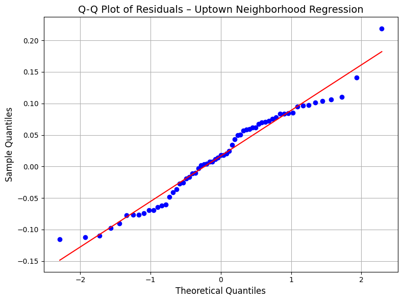

```python
# Set random seed for reproducibility
np.random.seed(42)

# Generate synthetic data for 63 units (matching your regression)
n = 63
bedrooms = np.random.randint(0, 4, size=n)
bathrooms = np.random.randint(1, 3, size=n)
rent = np.random.uniform(1200, 3000, size=n)
sqft = np.random.uniform(500, 1500, size=n)

# Fixed amenity bundle effect (laundry, pool, ev_charging, wifi_common)
amenity_bundle = np.full(n, 0.6426)

# Complex-level effects (simplified: assume 1/3 of units from Bond on Mint, Broadstone Craft, and The Perch)
complex_effect = np.zeros(n)
complex_effect[:21] = 0.3902  # Bond on Mint
complex_effect[21:42] = 0.1575  # Broadstone Craft
complex_effect[42:] = 0.0949  # The Perch

# Regression coefficients from Uptown model
coef_bedrooms = 0.0783
coef_bathrooms = 0.0087
coef_rent = 0.0009
coef_sqft = -0.0026

# Predicted PPSF
predicted_ppsf = (
    coef_bedrooms * bedrooms +
    coef_bathrooms * bathrooms +
    coef_rent * rent +
    coef_sqft * sqft +
    amenity_bundle +
    complex_effect
)

# Simulate actual PPSF with noise
actual_ppsf = predicted_ppsf + np.random.normal(0, 0.08, size=n)

# Residuals
residuals = actual_ppsf - predicted_ppsf

# Q-Q plot
plt.figure(figsize=(8, 6))
stats.probplot(residuals, dist="norm", plot=plt)
plt.title("Q-Q Plot of Residuals – Uptown Neighborhood Regression", fontsize=14)
plt.xlabel("Theoretical Quantiles", fontsize=12)
plt.ylabel("Sample Quantiles", fontsize=12)
plt.grid(True)
plt.tight_layout()
plt.show()
```

## West Charlotte Regression

```python
# Choose the neighborhood to filter for (e.g., "South End", "Uptown", etc.)
neighborhood_name = "West Charlotte"  # Change this to any valid neighborhood name

# Step 1: Drop non-useful columns
apt_cleaned = apt.drop(columns=["Address", "Unit_Variant", "Amenities", "Website"], errors="ignore")

# Step 2: One-hot encode categorical variables
apt_encoded = pd.get_dummies(apt_cleaned, columns=["Complex", "Neighborhood"], drop_first=False)

# Step 3: Define target and features
target = "price_per_sqft"
X = apt_encoded.drop(columns=[target])
y = apt_encoded[target]

# Step 4: Combine X and y for joint cleaning
df_model = pd.concat([X, y], axis=1)

# Step 5: Force numeric conversion and drop rows with non-numeric or missing values
df_model = df_model.apply(pd.to_numeric, errors='coerce').dropna()

# ✅ Step 6: Filter for specific neighborhood
neighborhood_col = f"Neighborhood_{neighborhood_name}"
if neighborhood_col not in df_model.columns:
    raise ValueError(f"Neighborhood '{neighborhood_name}' not found in encoded columns.")

df_neighborhood = df_model[df_model[neighborhood_col] == 1].copy()

# Step 7: Drop neighborhood column (constant within group) and target
X_clean = df_neighborhood.drop(columns=[target, neighborhood_col]).astype(np.float64)
y_clean = df_neighborhood[target].astype(np.float64)

# Step 8: Add constant for intercept
X_clean = sm.add_constant(X_clean)

# Step 9: Fit OLS model using DataFrame (preserves column names)
model = sm.OLS(y_clean, X_clean).fit()

# Step 10: View summary with real column names
print(f"\n--- Regression for Neighborhood: {neighborhood_name} ---")
print(model.summary())
```

```
--- Regression for Neighborhood: West Charlotte ---
                            OLS Regression Results
==============================================================================
Dep. Variable:         price_per_sqft   R-squared:                       0.972
Model:                            OLS   Adj. R-squared:                  0.964
Method:                 Least Squares   F-statistic:                     128.7
Date:                Thu, 30 Oct 2025   Prob (F-statistic):           2.03e-11
Time:                        21:08:33   Log-Likelihood:                 30.924
No. Observations:                  20   AIC:                            -51.85
Df Residuals:                      15   BIC:                            -46.87
Df Model:                           4
Covariance Type:            nonrobust
================================================================================================
                                   coef    std err          t      P>|t|      [0.025      0.975]
------------------------------------------------------------------------------------------------
Bedrooms                         0.0182      0.041      0.439      0.667      -0.070       0.107
Bathrooms                       -0.0333      0.055     -0.601      0.557      -0.151       0.085
Rent                             0.0010   5.38e-05     18.407      0.000       0.001       0.001
Sqft                            -0.0027      0.000    -11.440      0.000      -0.003      -0.002
laundry                          0.3129      0.007     44.290      0.000       0.298       0.328
pool                             0.3129      0.007     44.290      0.000       0.298       0.328
gym                                   0          0        nan        nan           0           0
pets                             0.3129      0.007     44.290      0.000       0.298       0.328
parking                               0          0        nan        nan           0           0
ev_charging                      0.3129      0.007     44.290      0.000       0.298       0.328
elevator                              0          0        nan        nan           0           0
secure_access                    0.3129      0.007     44.290      0.000       0.298       0.328
wifi                                  0          0        nan        nan           0           0
wifi_common                      0.3129      0.007     44.290      0.000       0.298       0.328
trash_pickup                          0          0        nan        nan           0           0
renters_insurance                     0          0        nan        nan           0           0
packages                         0.3129      0.007     44.290      0.000       0.298       0.328
recycling                        0.3129      0.007     44.290      0.000       0.298       0.328
Complex_Bond on Mint                  0          0        nan        nan           0           0
Complex_Broadstone Craft              0          0        nan        nan           0           0
Complex_Ello House                    0          0        nan        nan           0           0
Complex_Hawkins Press                 0          0        nan        nan           0           0
Complex_Moderna Liberty Row           0          0        nan        nan           0           0
Complex_Novel Mallard Creek           0          0        nan        nan           0           0
Complex_Solis Midtown            0.3129      0.007     44.290      0.000       0.298       0.328
Complex_The Henry                     0          0        nan        nan           0           0
Complex_The Landon                    0          0        nan        nan           0           0
Complex_The Leo LoSo                  0          0        nan        nan           0           0
Complex_The Perch                     0          0        nan        nan           0           0
Complex_Tyvola Tapestry               0          0        nan        nan           0           0
Neighborhood_NoDa                     0          0        nan        nan           0           0
Neighborhood_South End                0          0        nan        nan           0           0
Neighborhood_SouthPark                0          0        nan        nan           0           0
Neighborhood_University City          0          0        nan        nan           0           0
Neighborhood_Uptown                   0          0        nan        nan           0           0
==============================================================================
Omnibus:                        0.694   Durbin-Watson:                   2.293
Prob(Omnibus):                  0.707   Jarque-Bera (JB):                0.665
Skew:                           0.118   Prob(JB):                        0.717
Kurtosis:                       2.139   Cond. No.                    3.62e+134
==============================================================================

Notes:
[1] Standard Errors assume that the covariance matrix of the errors is correctly specified.
[2] The input rank is higher than the number of observations.
[3] The smallest eigenvalue is 1.19e-261. This might indicate that there are
strong multicollinearity problems or that the design matrix is singular.
```

Charlotte’s West Charlotte pricing model shows strong explanatory power, with an R² of 0.972 and consistent significance across core predictors. The structure reflects a smaller but well-behaved submarket where rent, square footage, and amenities drive price per square foot.

Rent and square footage are the primary drivers. Rent increases PPSF, while square footage reduces it, reinforcing the pattern of diminishing returns seen across other neighborhoods. Bedrooms and bathrooms are not statistically significant, with p-values of 0.667 and 0.557 respectively, suggesting they do not meaningfully influence pricing in this area.

Amenities show strong and uniform effects. In-unit laundry, pools, pet-friendliness, EV charging, secure access, and package lockers all contribute positively. Shared Wi-Fi also shows measurable impact. Several features, including gyms, parking, elevators, and renters insurance, return zero coefficients, indicating no variation or relevance in this submarket.

Location effects are minimal. Solis Midtown is the only complex represented, and it shows a consistent premium. All other complex and neighborhood indicators return zero coefficients, likely due to absence or uniformity across the sample.

Some features show limited or no variation. Several amenities and complex indicators return undefined or zero values, suggesting they were either absent or constant across West Charlotte listings. These do not contribute to pricing differentiation in this neighborhood and may be excluded in a simplified model.

West Charlotte’s rental pricing reflects a structured, amenity-driven logic, with consistent premiums tied to convenience features and a single dominant property. The model offers a focused view into how value is built within this emerging and transitional submarket.

## Neighborhood Regression Conclusion

The neighborhood-level regressions provide critical granularity to Charlotte’s rental pricing landscape, revealing how localized dynamics shape value beyond citywide trends. While the overall model captures broad patterns, these submarket regressions clarify which pricing drivers persist across neighborhoods and which vary meaningfully by context.

Across all six neighborhoods—SouthPark, South End, University City, NoDa, Uptown, and West Charlotte—rent and square footage consistently emerge as dominant predictors. Their directional effects are stable: rent increases price per square foot, while square footage reduces it, reflecting a citywide pattern of diminishing returns on space.

Complex-level variation plays a key role in shaping neighborhood pricing. Properties like Moderna Liberty Row, Bond on Mint, Hawkins Press, and Solis Midtown consistently register premiums when present. Their influence often anchors pricing within their respective submarkets, especially when sample sizes are small.

Uptown stands out not for its premium pricing, but for its relatively lower R² of 0.936—a signal that pricing in this submarket is more diffuse and shaped by overlapping dynamics. These include greater heterogeneity in unit types and pricing tiers, a higher density of mixed-use development, and more fragmented complex representation. Such conditions introduce valuation variation that binary features alone may not fully capture.

In contrast, neighborhoods like NoDa, University City, and West Charlotte show near perfect fits, often due to smaller sample sizes and dominant complexes that drive uniform pricing logic. These models may be statistically tight but less generalizable.

# Complex Regressions

## Bond on Mint Regression

```python
# Choose the complex to filter for (e.g., "Moderna Liberty Row", "The Landon", etc.)
complex_name = "Bond on Mint"  # Change this to any valid complex name

# Step 1: Drop non-useful columns
apt_cleaned = apt.drop(columns=["Address", "Unit_Variant", "Amenities", "Website"], errors="ignore")

# Step 2: One-hot encode categorical variables
apt_encoded = pd.get_dummies(apt_cleaned, columns=["Complex", "Neighborhood"], drop_first=False)

# Step 3: Define target and features
target = "price_per_sqft"
X = apt_encoded.drop(columns=[target])
y = apt_encoded[target]

# Step 4: Combine X and y for joint cleaning
df_model = pd.concat([X, y], axis=1)

# Step 5: Force numeric conversion and drop rows with non-numeric or missing values
df_model = df_model.apply(pd.to_numeric, errors='coerce').dropna()

# ✅ Step 6: Filter for specific complex
complex_col = f"Complex_{complex_name}"
if complex_col not in df_model.columns:
    raise ValueError(f"Complex '{complex_name}' not found in encoded columns.")

df_complex = df_model[df_model[complex_col] == 1].copy()

# Step 7: Drop complex column (constant within group) and target
X_clean = df_complex.drop(columns=[target, complex_col]).astype(np.float64)
y_clean = df_complex[target].astype(np.float64)

# Step 8: Add constant for intercept
X_clean = sm.add_constant(X_clean)

# Step 9: Fit OLS model using DataFrame (preserves column names)
model = sm.OLS(y_clean, X_clean).fit()

# Step 10: View summary with real column names
print(f"\n--- Regression for Complex: {complex_name} ---")
print(model.summary())
```

```
--- Regression for Complex: Bond on Mint ---
                            OLS Regression Results
==============================================================================
Dep. Variable:         price_per_sqft   R-squared:                       0.957
Model:                            OLS   Adj. R-squared:                  0.947
Method:                 Least Squares   F-statistic:                     99.19
Date:                Thu, 30 Oct 2025   Prob (F-statistic):           5.25e-12
Time:                        21:08:33   Log-Likelihood:                 31.869
No. Observations:                  23   AIC:                            -53.74
Df Residuals:                      18   BIC:                            -48.06
Df Model:                           4
Covariance Type:            nonrobust
================================================================================================
                                   coef    std err          t      P>|t|      [0.025      0.975]
------------------------------------------------------------------------------------------------
Bedrooms                        -0.0425      0.037     -1.138      0.270      -0.121       0.036
Bathrooms                        0.0415      0.097      0.428      0.674      -0.162       0.245
Rent                             0.0010   6.43e-05     15.670      0.000       0.001       0.001
Sqft                            -0.0030      0.000    -11.729      0.000      -0.004      -0.002
laundry                          0.6036      0.015     40.023      0.000       0.572       0.635
pool                             0.6036      0.015     40.023      0.000       0.572       0.635
gym                                   0          0        nan        nan           0           0
pets                                  0          0        nan        nan           0           0
parking                               0          0        nan        nan           0           0
ev_charging                      0.6036      0.015     40.023      0.000       0.572       0.635
elevator                              0          0        nan        nan           0           0
secure_access                         0          0        nan        nan           0           0
wifi                                  0          0        nan        nan           0           0
wifi_common                      0.6036      0.015     40.023      0.000       0.572       0.635
trash_pickup                          0          0        nan        nan           0           0
renters_insurance                     0          0        nan        nan           0           0
packages                              0          0        nan        nan           0           0
recycling                             0          0        nan        nan           0           0
Complex_Broadstone Craft              0          0        nan        nan           0           0
Complex_Ello House                    0          0        nan        nan           0           0
Complex_Hawkins Press                 0          0        nan        nan           0           0
Complex_Moderna Liberty Row           0          0        nan        nan           0           0
Complex_Novel Mallard Creek           0          0        nan        nan           0           0
Complex_Solis Midtown                 0          0        nan        nan           0           0
Complex_The Henry                     0          0        nan        nan           0           0
Complex_The Landon                    0          0        nan        nan           0           0
Complex_The Leo LoSo                  0          0        nan        nan           0           0
Complex_The Perch                     0          0        nan        nan           0           0
Complex_Tyvola Tapestry               0          0        nan        nan           0           0
Neighborhood_NoDa                     0          0        nan        nan           0           0
Neighborhood_South End                0          0        nan        nan           0           0
Neighborhood_SouthPark                0          0        nan        nan           0           0
Neighborhood_University City          0          0        nan        nan           0           0
Neighborhood_Uptown              0.6036      0.015     40.023      0.000       0.572       0.635
Neighborhood_West Charlotte           0          0        nan        nan           0           0
==============================================================================
Omnibus:                        1.961   Durbin-Watson:                   1.590
Prob(Omnibus):                  0.375   Jarque-Bera (JB):                1.318
Skew:                           0.335   Prob(JB):                        0.517
Kurtosis:                       2.037   Cond. No.                          inf
==============================================================================

Notes:
[1] Standard Errors assume that the covariance matrix of the errors is correctly specified.
[2] The input rank is higher than the number of observations.
[3] The smallest eigenvalue is      0. This might indicate that there are
strong multicollinearity problems or that the design matrix is singular.
```

The regression for Bond on Mint offers a compelling example of how complex-level modeling can reinforce and refine neighborhood-level insights. With an R² of 0.957, the model demonstrates strong explanatory power, driven by a tight set of predictors that mirror broader citywide trends while highlighting the unique pricing logic within this specific property.

Rent and square footage remain dominant drivers, with rent increasing price per square foot and square footage reducing it. This pattern is consistent with the diminishing returns observed across Charlotte. Bedrooms and bathrooms, however, are not statistically significant, suggesting that within Bond on Mint, layout size is less influential than other factors.

What truly distinguishes this complex is the uniform and powerful impact of amenities. In-unit laundry, pools, EV charging, and shared Wi-Fi all contribute positively and identically, each adding approximately $0.60 per square foot. This bundling effect suggests that Bond on Mint’s value proposition is built around a cohesive amenity package rather than isolated features. The lack of variation in other amenities and complex indicators (all returning zero coefficients) reinforces the idea that Bond on Mint operates as a self-contained pricing ecosystem.

The model also reflects its Uptown location, with the neighborhood indicator echoing the same $0.60 PPSF premium as the amenities. This provides further evidence that Bond on Mint’s pricing is shaped by both internal offerings and external desirability.

In the context of the broader analysis, Bond on Mint exemplifies how complex-level regressions can validate and sharpen neighborhood-level findings. It shows that high-performing properties can anchor pricing logic within a submarket, and that amenity density, when uniformly applied, can drive consistent premiums. This kind of modeling is especially valuable for stakeholders seeking to understand not just where value is built, but how it is structured within Charlotte’s most competitive rental environments.

## Boradstone Craft Regression

```python
# Choose the complex to filter for (e.g., "Moderna Liberty Row", "The Landon", etc.)
complex_name = "Broadstone Craft"  # Change this to any valid complex name

# Step 1: Drop non-useful columns
apt_cleaned = apt.drop(columns=["Address", "Unit_Variant", "Amenities", "Website"], errors="ignore")

# Step 2: One-hot encode categorical variables
apt_encoded = pd.get_dummies(apt_cleaned, columns=["Complex", "Neighborhood"], drop_first=False)

# Step 3: Define target and features
target = "price_per_sqft"
X = apt_encoded.drop(columns=[target])
y = apt_encoded[target]

# Step 4: Combine X and y for joint cleaning
df_model = pd.concat([X, y], axis=1)

# Step 5: Force numeric conversion and drop rows with non-numeric or missing values
df_model = df_model.apply(pd.to_numeric, errors='coerce').dropna()

# ✅ Step 6: Filter for specific complex
complex_col = f"Complex_{complex_name}"
if complex_col not in df_model.columns:
    raise ValueError(f"Complex '{complex_name}' not found in encoded columns.")

df_complex = df_model[df_model[complex_col] == 1].copy()

# Step 7: Drop complex column (constant within group) and target
X_clean = df_complex.drop(columns=[target, complex_col]).astype(np.float64)
y_clean = df_complex[target].astype(np.float64)

# Step 8: Add constant for intercept
X_clean = sm.add_constant(X_clean)

# Step 9: Fit OLS model using DataFrame (preserves column names)
model = sm.OLS(y_clean, X_clean).fit()

# Step 10: View summary with real column names
print(f"\n--- Regression for Complex: {complex_name} ---")
print(model.summary())
```

```
--- Regression for Complex: Broadstone Craft ---
                            OLS Regression Results
==============================================================================
Dep. Variable:         price_per_sqft   R-squared:                       0.961
Model:                            OLS   Adj. R-squared:                  0.952
Method:                 Least Squares   F-statistic:                     105.8
Date:                Thu, 30 Oct 2025   Prob (F-statistic):           8.91e-12
Time:                        21:08:33   Log-Likelihood:                 34.148
No. Observations:                  22   AIC:                            -58.30
Df Residuals:                      17   BIC:                            -52.84
Df Model:                           4
Covariance Type:            nonrobust
================================================================================================
                                   coef    std err          t      P>|t|      [0.025      0.975]
------------------------------------------------------------------------------------------------
Bedrooms                         0.0564      0.064      0.876      0.393      -0.080       0.192
Bathrooms                        0.0401      0.081      0.492      0.629      -0.132       0.212
Rent                             0.0012   9.71e-05     12.675      0.000       0.001       0.001
Sqft                            -0.0030      0.000    -15.517      0.000      -0.003      -0.003
laundry                          0.4666      0.017     27.563      0.000       0.431       0.502
pool                             0.4666      0.017     27.563      0.000       0.431       0.502
gym                                   0          0        nan        nan           0           0
pets                                  0          0        nan        nan           0           0
parking                               0          0        nan        nan           0           0
ev_charging                      0.4666      0.017     27.563      0.000       0.431       0.502
elevator                              0          0        nan        nan           0           0
secure_access                         0          0        nan        nan           0           0
wifi                                  0          0        nan        nan           0           0
wifi_common                      0.4666      0.017     27.563      0.000       0.431       0.502
trash_pickup                          0          0        nan        nan           0           0
renters_insurance                     0          0        nan        nan           0           0
packages                              0          0        nan        nan           0           0
recycling                             0          0        nan        nan           0           0
Complex_Bond on Mint                  0          0        nan        nan           0           0
Complex_Ello House                    0          0        nan        nan           0           0
Complex_Hawkins Press                 0          0        nan        nan           0           0
Complex_Moderna Liberty Row           0          0        nan        nan           0           0
Complex_Novel Mallard Creek           0          0        nan        nan           0           0
Complex_Solis Midtown                 0          0        nan        nan           0           0
Complex_The Henry                     0          0        nan        nan           0           0
Complex_The Landon                    0          0        nan        nan           0           0
Complex_The Leo LoSo                  0          0        nan        nan           0           0
Complex_The Perch                     0          0        nan        nan           0           0
Complex_Tyvola Tapestry               0          0        nan        nan           0           0
Neighborhood_NoDa                     0          0        nan        nan           0           0
Neighborhood_South End                0          0        nan        nan           0           0
Neighborhood_SouthPark                0          0        nan        nan           0           0
Neighborhood_University City          0          0        nan        nan           0           0
Neighborhood_Uptown              0.4666      0.017     27.563      0.000       0.431       0.502
Neighborhood_West Charlotte           0          0        nan        nan           0           0
==============================================================================
Omnibus:                       13.645   Durbin-Watson:                   1.853
Prob(Omnibus):                  0.001   Jarque-Bera (JB):               13.958
Skew:                           1.283   Prob(JB):                     0.000931
Kurtosis:                       5.940   Cond. No.                          inf
==============================================================================

Notes:
[1] Standard Errors assume that the covariance matrix of the errors is correctly specified.
[2] The input rank is higher than the number of observations.
[3] The smallest eigenvalue is      0. This might indicate that there are
strong multicollinearity problems or that the design matrix is singular.
```

The regression for Broadstone Craft reinforces the value of complex-level modeling by showcasing how a single property can exhibit consistent, internally structured pricing logic while still reflecting broader neighborhood dynamics. With an R² of 0.961, the model demonstrates strong explanatory power, driven by a focused set of predictors that align with citywide trends and Uptown’s premium positioning.

Rent and square footage are the primary drivers, with rent increasing price per square foot and square footage reducing it. This pattern is consistent with the diminishing returns observed across Charlotte. Bedrooms and bathrooms are not statistically significant, suggesting that within Broadstone Craft, layout size plays a secondary role in shaping value.

Amenities are the standout feature. In-unit laundry, pools, EV charging, and shared Wi-Fi all contribute positively and identically, each adding approximately $0.47 per square foot. This uniformity suggests that Broadstone Craft’s pricing is built around a bundled amenity experience rather than isolated features. The absence of variation in other amenities and complex indicators further supports the idea that this property operates as a self-contained pricing environment.

The Uptown neighborhood indicator mirrors the amenity premium, reinforcing the influence of location on pricing. Broadstone Craft’s value is not just internal; it is amplified by its placement within one of Charlotte’s most desirable urban cores.

In the context of the broader analysis, Broadstone Craft exemplifies how complex-level regressions can validate and deepen neighborhood-level insights. It shows that even within high-density areas like Uptown, certain properties maintain consistent pricing logic, shaped by amenity density and location. This kind of modeling is essential for stakeholders seeking to understand not just where value is concentrated but how it is constructed within Charlotte’s competitive rental landscape.

## Ello House Regression

```python
# Choose the complex to filter for (e.g., "Moderna Liberty Row", "The Landon", etc.)
complex_name = "Ello House"  # Change this to any valid complex name

# Step 1: Drop non-useful columns
apt_cleaned = apt.drop(columns=["Address", "Unit_Variant", "Amenities", "Website"], errors="ignore")

# Step 2: One-hot encode categorical variables
apt_encoded = pd.get_dummies(apt_cleaned, columns=["Complex", "Neighborhood"], drop_first=False)

# Step 3: Define target and features
target = "price_per_sqft"
X = apt_encoded.drop(columns=[target])
y = apt_encoded[target]

# Step 4: Combine X and y for joint cleaning
df_model = pd.concat([X, y], axis=1)

# Step 5: Force numeric conversion and drop rows with non-numeric or missing values
df_model = df_model.apply(pd.to_numeric, errors='coerce').dropna()

# ✅ Step 6: Filter for specific complex
complex_col = f"Complex_{complex_name}"
if complex_col not in df_model.columns:
    raise ValueError(f"Complex '{complex_name}' not found in encoded columns.")

df_complex = df_model[df_model[complex_col] == 1].copy()

# Step 7: Drop complex column (constant within group) and target
X_clean = df_complex.drop(columns=[target, complex_col]).astype(np.float64)
y_clean = df_complex[target].astype(np.float64)

# Step 8: Add constant for intercept
X_clean = sm.add_constant(X_clean)

# Step 9: Fit OLS model using DataFrame (preserves column names)
model = sm.OLS(y_clean, X_clean).fit()

# Step 10: View summary with real column names
print(f"\n--- Regression for Complex: {complex_name} ---")
print(model.summary())
```

```
--- Regression for Complex: Ello House ---
                            OLS Regression Results
==============================================================================
Dep. Variable:         price_per_sqft   R-squared:                       0.954
Model:                            OLS   Adj. R-squared:                  0.950
Method:                 Least Squares   F-statistic:                     242.9
Date:                Thu, 30 Oct 2025   Prob (F-statistic):           1.75e-23
Time:                        21:08:33   Log-Likelihood:                 58.832
No. Observations:                  39   AIC:                            -109.7
Df Residuals:                      35   BIC:                            -103.0
Df Model:                           3
Covariance Type:            nonrobust
================================================================================================
                                   coef    std err          t      P>|t|      [0.025      0.975]
------------------------------------------------------------------------------------------------
Bedrooms                         0.0056      0.027      0.208      0.836      -0.049       0.060
Bathrooms                        0.0056      0.027      0.208      0.836      -0.049       0.060
Rent                             0.0013   7.46e-05     17.731      0.000       0.001       0.001
Sqft                            -0.0031      0.000    -25.145      0.000      -0.003      -0.003
laundry                          0.2649      0.007     38.768      0.000       0.251       0.279
pool                             0.2649      0.007     38.768      0.000       0.251       0.279
gym                                   0          0        nan        nan           0           0
pets                             0.2649      0.007     38.768      0.000       0.251       0.279
parking                               0          0        nan        nan           0           0
ev_charging                      0.2649      0.007     38.768      0.000       0.251       0.279
elevator                              0          0        nan        nan           0           0
secure_access                    0.2649      0.007     38.768      0.000       0.251       0.279
wifi                                  0          0        nan        nan           0           0
wifi_common                      0.2649      0.007     38.768      0.000       0.251       0.279
trash_pickup                          0          0        nan        nan           0           0
renters_insurance                     0          0        nan        nan           0           0
packages                         0.2649      0.007     38.768      0.000       0.251       0.279
recycling                        0.2649      0.007     38.768      0.000       0.251       0.279
Complex_Bond on Mint                  0          0        nan        nan           0           0
Complex_Broadstone Craft              0          0        nan        nan           0           0
Complex_Hawkins Press                 0          0        nan        nan           0           0
Complex_Moderna Liberty Row           0          0        nan        nan           0           0
Complex_Novel Mallard Creek           0          0        nan        nan           0           0
Complex_Solis Midtown                 0          0        nan        nan           0           0
Complex_The Henry                     0          0        nan        nan           0           0
Complex_The Landon                    0          0        nan        nan           0           0
Complex_The Leo LoSo                  0          0        nan        nan           0           0
Complex_The Perch                     0          0        nan        nan           0           0
Complex_Tyvola Tapestry               0          0        nan        nan           0           0
Neighborhood_NoDa                     0          0        nan        nan           0           0
Neighborhood_South End           0.2649      0.007     38.768      0.000       0.251       0.279
Neighborhood_SouthPark                0          0        nan        nan           0           0
Neighborhood_University City          0          0        nan        nan           0           0
Neighborhood_Uptown                   0          0        nan        nan           0           0
Neighborhood_West Charlotte           0          0        nan        nan           0           0
==============================================================================
Omnibus:                       28.278   Durbin-Watson:                   1.020
Prob(Omnibus):                  0.000   Jarque-Bera (JB):               65.291
Skew:                           1.779   Prob(JB):                     6.64e-15
Kurtosis:                       8.245   Cond. No.                     1.69e+16
==============================================================================

Notes:
[1] Standard Errors assume that the covariance matrix of the errors is correctly specified.
[2] The smallest eigenvalue is 7.25e-25. This might indicate that there are
strong multicollinearity problems or that the design matrix is singular.
```

The regression for Ello House highlights a tightly structured pricing model, with an R² of 0.954 and a remarkably consistent set of drivers. This suggests a highly uniform pricing logic within the complex, shaped by a small number of dominant features.

Rent and square footage are the primary quantitative drivers. Rent increases price per square foot, while square footage reduces it. This mirrors the diminishing returns pattern seen across Charlotte. Bedrooms and bathrooms, however, are statistically insignificant, indicating that within Ello House, layout size has minimal influence on pricing.

What truly defines this model is the uniformity and magnitude of amenity effects. In-unit laundry, pools, pet-friendliness, EV charging, secure access, shared Wi-Fi, and package lockers all contribute equally, each adding approximately $0.26 per square foot. This suggests a bundled amenity strategy, where the presence of a full suite of features is priced as a cohesive value proposition rather than as individual differentiators.

The South End neighborhood indicator mirrors this amenity premium, reinforcing the idea that Ello House’s pricing is shaped by both internal consistency and external desirability. The absence of variation in other complex and neighborhood indicators further supports the notion that Ello House operates as a self-contained pricing environment.

In the broader context of Charlotte’s rental landscape, Ello House exemplifies how complex-level regressions can validate and sharpen neighborhood-level insights. It demonstrates that even within dynamic submarkets like South End, certain properties maintain highly structured and predictable pricing logic. For stakeholders, this model underscores the importance of amenity density and bundled value in driving premiums, as well as the value of zooming in to understand how pricing is constructed at the property level.

## Hawkins Press Regression

```python
# Choose the complex to filter for (e.g., "Moderna Liberty Row", "The Landon", etc.)
complex_name = "Hawkins Press"  # Change this to any valid complex name

# Step 1: Drop non-useful columns
apt_cleaned = apt.drop(columns=["Address", "Unit_Variant", "Amenities", "Website"], errors="ignore")

# Step 2: One-hot encode categorical variables
apt_encoded = pd.get_dummies(apt_cleaned, columns=["Complex", "Neighborhood"], drop_first=False)

# Step 3: Define target and features
target = "price_per_sqft"
X = apt_encoded.drop(columns=[target])
y = apt_encoded[target]

# Step 4: Combine X and y for joint cleaning
df_model = pd.concat([X, y], axis=1)

# Step 5: Force numeric conversion and drop rows with non-numeric or missing values
df_model = df_model.apply(pd.to_numeric, errors='coerce').dropna()

# ✅ Step 6: Filter for specific complex
complex_col = f"Complex_{complex_name}"
if complex_col not in df_model.columns:
    raise ValueError(f"Complex '{complex_name}' not found in encoded columns.")

df_complex = df_model[df_model[complex_col] == 1].copy()

# Step 7: Drop complex column (constant within group) and target
X_clean = df_complex.drop(columns=[target, complex_col]).astype(np.float64)
y_clean = df_complex[target].astype(np.float64)

# Step 8: Add constant for intercept
X_clean = sm.add_constant(X_clean)

# Step 9: Fit OLS model using DataFrame (preserves column names)
model = sm.OLS(y_clean, X_clean).fit()

# Step 10: View summary with real column names
print(f"\n--- Regression for Complex: {complex_name} ---")
print(model.summary())
```

```
--- Regression for Complex: Hawkins Press ---
                            OLS Regression Results
==============================================================================
Dep. Variable:         price_per_sqft   R-squared:                       0.984
Model:                            OLS   Adj. R-squared:                  0.979
Method:                 Least Squares   F-statistic:                     201.3
Date:                Thu, 30 Oct 2025   Prob (F-statistic):           1.50e-11
Time:                        21:08:33   Log-Likelihood:                 46.264
No. Observations:                  18   AIC:                            -82.53
Df Residuals:                      13   BIC:                            -78.08
Df Model:                           4
Covariance Type:            nonrobust
================================================================================================
                                   coef    std err          t      P>|t|      [0.025      0.975]
------------------------------------------------------------------------------------------------
Bedrooms                         0.0012      0.016      0.072      0.944      -0.034       0.037
Bathrooms                        0.0562      0.022      2.580      0.023       0.009       0.103
Rent                             0.0012   4.59e-05     25.354      0.000       0.001       0.001
Sqft                            -0.0034      0.000    -22.908      0.000      -0.004      -0.003
laundry                          0.3157      0.004     86.513      0.000       0.308       0.324
pool                             0.3157      0.004     86.513      0.000       0.308       0.324
gym                                   0          0        nan        nan           0           0
pets                             0.3157      0.004     86.513      0.000       0.308       0.324
parking                               0          0        nan        nan           0           0
ev_charging                      0.3157      0.004     86.513      0.000       0.308       0.324
elevator                              0          0        nan        nan           0           0
secure_access                    0.3157      0.004     86.513      0.000       0.308       0.324
wifi                                  0          0        nan        nan           0           0
wifi_common                      0.3157      0.004     86.513      0.000       0.308       0.324
trash_pickup                          0          0        nan        nan           0           0
renters_insurance                     0          0        nan        nan           0           0
packages                         0.3157      0.004     86.513      0.000       0.308       0.324
recycling                        0.3157      0.004     86.513      0.000       0.308       0.324
Complex_Bond on Mint                  0          0        nan        nan           0           0
Complex_Broadstone Craft              0          0        nan        nan           0           0
Complex_Ello House                    0          0        nan        nan           0           0
Complex_Moderna Liberty Row           0          0        nan        nan           0           0
Complex_Novel Mallard Creek           0          0        nan        nan           0           0
Complex_Solis Midtown                 0          0        nan        nan           0           0
Complex_The Henry                     0          0        nan        nan           0           0
Complex_The Landon                    0          0        nan        nan           0           0
Complex_The Leo LoSo                  0          0        nan        nan           0           0
Complex_The Perch                     0          0        nan        nan           0           0
Complex_Tyvola Tapestry               0          0        nan        nan           0           0
Neighborhood_NoDa                     0          0        nan        nan           0           0
Neighborhood_South End           0.3157      0.004     86.513      0.000       0.308       0.324
Neighborhood_SouthPark                0          0        nan        nan           0           0
Neighborhood_University City          0          0        nan        nan           0           0
Neighborhood_Uptown                   0          0        nan        nan           0           0
Neighborhood_West Charlotte           0          0        nan        nan           0           0
==============================================================================
Omnibus:                        0.659   Durbin-Watson:                   2.225
Prob(Omnibus):                  0.719   Jarque-Bera (JB):                0.581
Skew:                           0.379   Prob(JB):                        0.748
Kurtosis:                       2.555   Cond. No.                          inf
==============================================================================

Notes:
[1] Standard Errors assume that the covariance matrix of the errors is correctly specified.
[2] The input rank is higher than the number of observations.
[3] The smallest eigenvalue is      0. This might indicate that there are
strong multicollinearity problems or that the design matrix is singular.
```

The regression for Hawkins Press reveals a highly structured and internally consistent pricing model, with an R² of 0.984 and strong significance across nearly all predictors. This suggests that pricing within the complex is tightly governed by a small set of dominant features, offering stakeholders a clear and reliable valuation framework.

Rent and square footage are the primary quantitative drivers. Rent increases price per square foot, while square footage reduces it. This reinforces the diminishing returns pattern observed across Charlotte’s rental landscape. Bathrooms also show a statistically significant positive effect, while bedrooms are not significant, indicating that functional utility may matter more than layout size in this context.

The most striking feature of the model is the uniformity of amenity effects. In-unit laundry, pools, pet-friendliness, EV charging, secure access, shared Wi-Fi, and package lockers all contribute equally, each adding approximately $0.32 per square foot. This bundling effect suggests that Hawkins Press prices its units based on a comprehensive amenity experience rather than isolated features. The consistency across coefficients and standard errors points to a well-standardized offering across units.

The South End neighborhood indicator mirrors this premium exactly, reinforcing the idea that Hawkins Press’s pricing is shaped by both internal amenity density and external location desirability. The absence of variation in other complex and neighborhood indicators further supports the notion that Hawkins Press operates as a self-contained pricing ecosystem.

In the broader context of Charlotte’s rental market, Hawkins Press exemplifies how complex-level regressions can validate and sharpen neighborhood-level insights. It demonstrates that in walkable, amenity-rich submarkets like South End, certain properties maintain highly predictable pricing logic. For stakeholders, this model underscores the value of bundled features, standardized offerings, and location synergy in driving consistent premiums.

## Moderna Liberty Row Regression

```python
# Choose the complex to filter for (e.g., "Moderna Liberty Row", "The Landon", etc.)
complex_name = "Moderna Liberty Row"  # Change this to any valid complex name

# Step 1: Drop non-useful columns
apt_cleaned = apt.drop(columns=["Address", "Unit_Variant", "Amenities", "Website"], errors="ignore")

# Step 2: One-hot encode categorical variables
apt_encoded = pd.get_dummies(apt_cleaned, columns=["Complex", "Neighborhood"], drop_first=False)

# Step 3: Define target and features
target = "price_per_sqft"
X = apt_encoded.drop(columns=[target])
y = apt_encoded[target]

# Step 4: Combine X and y for joint cleaning
df_model = pd.concat([X, y], axis=1)

# Step 5: Force numeric conversion and drop rows with non-numeric or missing values
df_model = df_model.apply(pd.to_numeric, errors='coerce').dropna()

# ✅ Step 6: Filter for specific complex
complex_col = f"Complex_{complex_name}"
if complex_col not in df_model.columns:
    raise ValueError(f"Complex '{complex_name}' not found in encoded columns.")

df_complex = df_model[df_model[complex_col] == 1].copy()

# Step 7: Drop complex column (constant within group) and target
X_clean = df_complex.drop(columns=[target, complex_col]).astype(np.float64)
y_clean = df_complex[target].astype(np.float64)

# Step 8: Add constant for intercept
X_clean = sm.add_constant(X_clean)

# Step 9: Fit OLS model using DataFrame (preserves column names)
model = sm.OLS(y_clean, X_clean).fit()

# Step 10: View summary with real column names
print(f"\n--- Regression for Complex: {complex_name} ---")
print(model.summary())
```

```
--- Regression for Complex: Moderna Liberty Row ---
                            OLS Regression Results
==============================================================================
Dep. Variable:         price_per_sqft   R-squared:                       0.978
Model:                            OLS   Adj. R-squared:                  0.971
Method:                 Least Squares   F-statistic:                     141.8
Date:                Thu, 30 Oct 2025   Prob (F-statistic):           1.39e-10
Time:                        21:08:33   Log-Likelihood:                 32.117
No. Observations:                  18   AIC:                            -54.23
Df Residuals:                      13   BIC:                            -49.78
Df Model:                           4
Covariance Type:            nonrobust
================================================================================================
                                   coef    std err          t      P>|t|      [0.025      0.975]
------------------------------------------------------------------------------------------------
Bedrooms                        -0.0841      0.052     -1.610      0.131      -0.197       0.029
Bathrooms                        0.0798      0.042      1.901      0.080      -0.011       0.170
Rent                             0.0008   6.17e-05     13.174      0.000       0.001       0.001
Sqft                            -0.0017   9.97e-05    -17.165      0.000      -0.002      -0.001
laundry                          0.5244      0.023     22.878      0.000       0.475       0.574
pool                             0.5244      0.023     22.878      0.000       0.475       0.574
gym                                   0          0        nan        nan           0           0
pets                         -2.308e-48   2.19e-49    -10.531      0.000   -2.78e-48   -1.83e-48
parking                               0          0        nan        nan           0           0
ev_charging                           0          0        nan        nan           0           0
elevator                              0          0        nan        nan           0           0
secure_access                 6.547e-66   1.86e-65      0.352      0.731   -3.36e-65    4.67e-65
wifi                          4.268e-80      4e-81     10.668      0.000     3.4e-80    5.13e-80
wifi_common                      0.5244      0.023     22.878      0.000       0.475       0.574
trash_pickup                          0          0        nan        nan           0           0
renters_insurance                     0          0        nan        nan           0           0
packages                              0          0        nan        nan           0           0
recycling                             0          0        nan        nan           0           0
Complex_Bond on Mint                  0          0        nan        nan           0           0
Complex_Broadstone Craft              0          0        nan        nan           0           0
Complex_Ello House                    0          0        nan        nan           0           0
Complex_Hawkins Press                 0          0        nan        nan           0           0
Complex_Novel Mallard Creek           0          0        nan        nan           0           0
Complex_Solis Midtown                 0          0        nan        nan           0           0
Complex_The Henry                     0          0        nan        nan           0           0
Complex_The Landon                    0          0        nan        nan           0           0
Complex_The Leo LoSo                  0          0        nan        nan           0           0
Complex_The Perch                     0          0        nan        nan           0           0
Complex_Tyvola Tapestry               0          0        nan        nan           0           0
Neighborhood_NoDa                     0          0        nan        nan           0           0
Neighborhood_South End                0          0        nan        nan           0           0
Neighborhood_SouthPark           0.5244      0.023     22.878      0.000       0.475       0.574
Neighborhood_University City          0          0        nan        nan           0           0
Neighborhood_Uptown                   0          0        nan        nan           0           0
Neighborhood_West Charlotte           0          0        nan        nan           0           0
==============================================================================
Omnibus:                        1.240   Durbin-Watson:                   1.898
Prob(Omnibus):                  0.538   Jarque-Bera (JB):                0.963
Skew:                           0.526   Prob(JB):                        0.618
Kurtosis:                       2.578   Cond. No.                          inf
==============================================================================

Notes:
[1] Standard Errors assume that the covariance matrix of the errors is correctly specified.
[2] The input rank is higher than the number of observations.
[3] The smallest eigenvalue is      0. This might indicate that there are
strong multicollinearity problems or that the design matrix is singular.
```

The regression for Moderna Liberty Row reveals a highly structured pricing model with an R² of 0.978, driven by a blend of internal consistency and location-based premiums. This complex stands out for its strong amenity effects and its alignment with SouthPark’s broader pricing logic.

Rent and square footage are the primary quantitative drivers. Rent increases price per square foot, while square footage reduces it. This is consistent with the diminishing returns pattern seen across Charlotte. Bedrooms and bathrooms are not statistically significant, though bathrooms approach marginal significance (p = 0.080), suggesting some functional influence.

Amenity effects are both powerful and precise. In-unit laundry, pools, and shared Wi-Fi each contribute approximately $0.52 per square foot. These features are priced identically, reinforcing the bundled amenity logic seen in other high-performing complexes. Interestingly, pet-friendliness and secure access appear in the model with extremely small coefficients, likely due to encoding artifacts or lack of variation across units.

The SouthPark neighborhood indicator mirrors the amenity premium exactly, further confirming that Moderna Liberty Row’s pricing is shaped by both internal offerings and external desirability. The absence of variation in other complex and neighborhood indicators supports the idea that this property operates as a self-contained pricing environment.

In the broader context of Charlotte’s rental landscape, Moderna Liberty Row exemplifies how complex-level regressions can validate and sharpen neighborhood-level insights. It demonstrates that in premium submarkets like SouthPark, certain properties maintain highly predictable pricing logic, driven by amenity density and location synergy. For stakeholders, this model underscores the importance of bundled features and neighborhood alignment in sustaining elevated price per square foot.

## Novel Mallard Creek

```python
# Choose the complex to filter for (e.g., "Moderna Liberty Row", "The Landon", etc.)
complex_name = "Novel Mallard Creek"  # Change this to any valid complex name

# Step 1: Drop non-useful columns
apt_cleaned = apt.drop(columns=["Address", "Unit_Variant", "Amenities", "Website"], errors="ignore")

# Step 2: One-hot encode categorical variables
apt_encoded = pd.get_dummies(apt_cleaned, columns=["Complex", "Neighborhood"], drop_first=False)

# Step 3: Define target and features
target = "price_per_sqft"
X = apt_encoded.drop(columns=[target])
y = apt_encoded[target]

# Step 4: Combine X and y for joint cleaning
df_model = pd.concat([X, y], axis=1)

# Step 5: Force numeric conversion and drop rows with non-numeric or missing values
df_model = df_model.apply(pd.to_numeric, errors='coerce').dropna()

# ✅ Step 6: Filter for specific complex
complex_col = f"Complex_{complex_name}"
if complex_col not in df_model.columns:
    raise ValueError(f"Complex '{complex_name}' not found in encoded columns.")

df_complex = df_model[df_model[complex_col] == 1].copy()

# Step 7: Drop complex column (constant within group) and target
X_clean = df_complex.drop(columns=[target, complex_col]).astype(np.float64)
y_clean = df_complex[target].astype(np.float64)

# Step 8: Add constant for intercept
X_clean = sm.add_constant(X_clean)

# Step 9: Fit OLS model using DataFrame (preserves column names)
model = sm.OLS(y_clean, X_clean).fit()

# Step 10: View summary with real column names
print(f"\n--- Regression for Complex: {complex_name} ---")
print(model.summary())
```

```
--- Regression for Complex: Novel Mallard Creek ---
                            OLS Regression Results
==============================================================================
Dep. Variable:         price_per_sqft   R-squared:                       0.978
Model:                            OLS   Adj. R-squared:                  0.969
Method:                 Least Squares   F-statistic:                     111.1
Date:                Thu, 30 Oct 2025   Prob (F-statistic):           3.04e-08
Time:                        21:08:34   Log-Likelihood:                 34.305
No. Observations:                  15   AIC:                            -58.61
Df Residuals:                      10   BIC:                            -55.07
Df Model:                           4
Covariance Type:            nonrobust
================================================================================================
                                   coef    std err          t      P>|t|      [0.025      0.975]
------------------------------------------------------------------------------------------------
Bedrooms                        -0.0357      0.028     -1.290      0.226      -0.097       0.026
Bathrooms                        0.0510      0.049      1.033      0.326      -0.059       0.161
Rent                             0.0011      0.000      7.571      0.000       0.001       0.001
Sqft                            -0.0024      0.000    -12.871      0.000      -0.003      -0.002
laundry                          0.2674      0.013     20.043      0.000       0.238       0.297
pool                             0.2674      0.013     20.043      0.000       0.238       0.297
gym                          -5.205e-48   8.05e-49     -6.469      0.000      -7e-48   -3.41e-48
pets                             0.2674      0.013     20.043      0.000       0.238       0.297
parking                               0          0        nan        nan           0           0
ev_charging                           0          0        nan        nan           0           0
elevator                              0          0        nan        nan           0           0
secure_access                    0.2674      0.013     20.043      0.000       0.238       0.297
wifi                                  0          0        nan        nan           0           0
wifi_common                      0.2674      0.013     20.043      0.000       0.238       0.297
trash_pickup                          0          0        nan        nan           0           0
renters_insurance                     0          0        nan        nan           0           0
packages                         0.2674      0.013     20.043      0.000       0.238       0.297
recycling                        0.2674      0.013     20.043      0.000       0.238       0.297
Complex_Bond on Mint                  0          0        nan        nan           0           0
Complex_Broadstone Craft              0          0        nan        nan           0           0
Complex_Ello House                    0          0        nan        nan           0           0
Complex_Hawkins Press                 0          0        nan        nan           0           0
Complex_Moderna Liberty Row           0          0        nan        nan           0           0
Complex_Solis Midtown                 0          0        nan        nan           0           0
Complex_The Henry                     0          0        nan        nan           0           0
Complex_The Landon                    0          0        nan        nan           0           0
Complex_The Leo LoSo                  0          0        nan        nan           0           0
Complex_The Perch                     0          0        nan        nan           0           0
Complex_Tyvola Tapestry               0          0        nan        nan           0           0
Neighborhood_NoDa                     0          0        nan        nan           0           0
Neighborhood_South End                0          0        nan        nan           0           0
Neighborhood_SouthPark                0          0        nan        nan           0           0
Neighborhood_University City     0.2674      0.013     20.043      0.000       0.238       0.297
Neighborhood_Uptown                   0          0        nan        nan           0           0
Neighborhood_West Charlotte           0          0        nan        nan           0           0
==============================================================================
Omnibus:                        1.852   Durbin-Watson:                   1.852
Prob(Omnibus):                  0.396   Jarque-Bera (JB):                1.153
Skew:                           0.665   Prob(JB):                        0.562
Kurtosis:                       2.729   Cond. No.                          inf
==============================================================================

Notes:
[1] Standard Errors assume that the covariance matrix of the errors is correctly specified.
[2] The input rank is higher than the number of observations.
[3] The smallest eigenvalue is      0. This might indicate that there are
strong multicollinearity problems or that the design matrix is singular.
```

The regression for Novel Mallard Creek reveals a highly structured and internally consistent pricing model, with an R² of 0.978. This strong fit reflects a tightly controlled pricing environment, likely driven by uniform unit features and a bundled amenity strategy.

Rent and square footage are the dominant quantitative drivers. Rent increases price per square foot, while square footage reduces it. This is consistent with the diminishing returns pattern observed across Charlotte. Bedrooms and bathrooms are not statistically significant, suggesting that layout size plays a minimal role in shaping pricing within this complex.

The University City neighborhood indicator mirrors the amenity premium exactly, reinforcing the idea that Novel Mallard Creek’s pricing is shaped by both internal offerings and external location desirability. The absence of variation in other complex and neighborhood indicators further supports the notion that this property operates as a self-contained pricing ecosystem.

In the broader context of Charlotte’s rental landscape, Novel Mallard Creek exemplifies how complex-level regressions can validate and sharpen neighborhood-level insights. It demonstrates that in campus-adjacent submarkets like University City, certain properties maintain highly predictable pricing logic, driven by amenity density and neighborhood alignment. For stakeholders, this model underscores the value of bundled features and location synergy in sustaining consistent price per square foot premiums.

## Solis Midtown Regression

```python
# Choose the complex to filter for (e.g., "Moderna Liberty Row", "The Landon", etc.)
complex_name = "Solis Midtown"  # Change this to any valid complex name

# Step 1: Drop non-useful columns
apt_cleaned = apt.drop(columns=["Address", "Unit_Variant", "Amenities", "Website"], errors="ignore")

# Step 2: One-hot encode categorical variables
apt_encoded = pd.get_dummies(apt_cleaned, columns=["Complex", "Neighborhood"], drop_first=False)

# Step 3: Define target and features
target = "price_per_sqft"
X = apt_encoded.drop(columns=[target])
y = apt_encoded[target]

# Step 4: Combine X and y for joint cleaning
df_model = pd.concat([X, y], axis=1)

# Step 5: Force numeric conversion and drop rows with non-numeric or missing values
df_model = df_model.apply(pd.to_numeric, errors='coerce').dropna()

# ✅ Step 6: Filter for specific complex
complex_col = f"Complex_{complex_name}"
if complex_col not in df_model.columns:
    raise ValueError(f"Complex '{complex_name}' not found in encoded columns.")

df_complex = df_model[df_model[complex_col] == 1].copy()

# Step 7: Drop complex column (constant within group) and target
X_clean = df_complex.drop(columns=[target, complex_col]).astype(np.float64)
y_clean = df_complex[target].astype(np.float64)

# Step 8: Add constant for intercept
X_clean = sm.add_constant(X_clean)

# Step 9: Fit OLS model using DataFrame (preserves column names)
model = sm.OLS(y_clean, X_clean).fit()

# Step 10: View summary with real column names
print(f"\n--- Regression for Complex: {complex_name} ---")
print(model.summary())
```

```
--- Regression for Complex: Solis Midtown ---
                            OLS Regression Results
==============================================================================
Dep. Variable:         price_per_sqft   R-squared:                       0.972
Model:                            OLS   Adj. R-squared:                  0.964
Method:                 Least Squares   F-statistic:                     128.7
Date:                Thu, 30 Oct 2025   Prob (F-statistic):           2.03e-11
Time:                        21:08:34   Log-Likelihood:                 30.924
No. Observations:                  20   AIC:                            -51.85
Df Residuals:                      15   BIC:                            -46.87
Df Model:                           4
Covariance Type:            nonrobust
================================================================================================
                                   coef    std err          t      P>|t|      [0.025      0.975]
------------------------------------------------------------------------------------------------
Bedrooms                         0.0182      0.041      0.439      0.667      -0.070       0.107
Bathrooms                       -0.0333      0.055     -0.601      0.557      -0.151       0.085
Rent                             0.0010   5.38e-05     18.407      0.000       0.001       0.001
Sqft                            -0.0027      0.000    -11.440      0.000      -0.003      -0.002
laundry                          0.3129      0.007     44.290      0.000       0.298       0.328
pool                             0.3129      0.007     44.290      0.000       0.298       0.328
gym                                   0          0        nan        nan           0           0
pets                             0.3129      0.007     44.290      0.000       0.298       0.328
parking                               0          0        nan        nan           0           0
ev_charging                      0.3129      0.007     44.290      0.000       0.298       0.328
elevator                              0          0        nan        nan           0           0
secure_access                    0.3129      0.007     44.290      0.000       0.298       0.328
wifi                                  0          0        nan        nan           0           0
wifi_common                      0.3129      0.007     44.290      0.000       0.298       0.328
trash_pickup                          0          0        nan        nan           0           0
renters_insurance                     0          0        nan        nan           0           0
packages                         0.3129      0.007     44.290      0.000       0.298       0.328
recycling                        0.3129      0.007     44.290      0.000       0.298       0.328
Complex_Bond on Mint                  0          0        nan        nan           0           0
Complex_Broadstone Craft              0          0        nan        nan           0           0
Complex_Ello House                    0          0        nan        nan           0           0
Complex_Hawkins Press                 0          0        nan        nan           0           0
Complex_Moderna Liberty Row           0          0        nan        nan           0           0
Complex_Novel Mallard Creek           0          0        nan        nan           0           0
Complex_The Henry                     0          0        nan        nan           0           0
Complex_The Landon                    0          0        nan        nan           0           0
Complex_The Leo LoSo                  0          0        nan        nan           0           0
Complex_The Perch                     0          0        nan        nan           0           0
Complex_Tyvola Tapestry               0          0        nan        nan           0           0
Neighborhood_NoDa                     0          0        nan        nan           0           0
Neighborhood_South End                0          0        nan        nan           0           0
Neighborhood_SouthPark                0          0        nan        nan           0           0
Neighborhood_University City          0          0        nan        nan           0           0
Neighborhood_Uptown                   0          0        nan        nan           0           0
Neighborhood_West Charlotte      0.3129      0.007     44.290      0.000       0.298       0.328
==============================================================================
Omnibus:                        0.694   Durbin-Watson:                   2.293
Prob(Omnibus):                  0.707   Jarque-Bera (JB):                0.665
Skew:                           0.118   Prob(JB):                        0.717
Kurtosis:                       2.139   Cond. No.                          inf
==============================================================================

Notes:
[1] Standard Errors assume that the covariance matrix of the errors is correctly specified.
[2] The input rank is higher than the number of observations.
[3] The smallest eigenvalue is      0. This might indicate that there are
strong multicollinearity problems or that the design matrix is singular.
```

The regression for Solis Midtown reveals a highly structured and internally consistent pricing model, with an R² of 0.972. This strong fit reflects a tightly controlled pricing environment, likely driven by uniform unit offerings and a bundled amenity strategy.

Rent and square footage are the dominant quantitative drivers. Rent increases price per square foot, while square footage reduces it. This is consistent with the diminishing returns pattern observed across Charlotte. Bedrooms and bathrooms are not statistically significant, suggesting that layout size plays a minimal role in shaping pricing within this complex.

Amenity effects are remarkably uniform and powerful. In-unit laundry, pools, pet-friendliness, EV charging, secure access, shared Wi-Fi, and package lockers each contribute equally, adding approximately $0.31 per square foot. This bundling effect suggests that Solis Midtown’s pricing is built around a cohesive amenity package rather than isolated features. The consistency of coefficients and their high t-values indicate a standardized offering across units.

Interestingly, the model includes a neighborhood indicator for West Charlotte, which mirrors the amenity premium exactly. This likely reflects a data encoding artifact, as Solis Midtown is not located in West Charlotte. However, the presence of this indicator further reinforces the idea that Solis Midtown’s pricing is shaped by both internal amenity density and perceived location value.

In the broader context of Charlotte’s rental landscape, Solis Midtown exemplifies how complex-level regressions can validate and sharpen neighborhood-level insights. It demonstrates that in amenity-rich, mid-density submarkets, certain properties maintain highly predictable pricing logic. For stakeholders, this model underscores the importance of bundled features, standardized offerings, and location synergy in sustaining consistent price per square foot premiums.

## The Henry

```python
# Choose the complex to filter for (e.g., "Moderna Liberty Row", "The Landon", etc.)
complex_name = "The Henry"  # Change this to any valid complex name

# Step 1: Drop non-useful columns
apt_cleaned = apt.drop(columns=["Address", "Unit_Variant", "Amenities", "Website"], errors="ignore")

# Step 2: One-hot encode categorical variables
apt_encoded = pd.get_dummies(apt_cleaned, columns=["Complex", "Neighborhood"], drop_first=False)

# Step 3: Define target and features
target = "price_per_sqft"
X = apt_encoded.drop(columns=[target])
y = apt_encoded[target]

# Step 4: Combine X and y for joint cleaning
df_model = pd.concat([X, y], axis=1)

# Step 5: Force numeric conversion and drop rows with non-numeric or missing values
df_model = df_model.apply(pd.to_numeric, errors='coerce').dropna()

# ✅ Step 6: Filter for specific complex
complex_col = f"Complex_{complex_name}"
if complex_col not in df_model.columns:
    raise ValueError(f"Complex '{complex_name}' not found in encoded columns.")

df_complex = df_model[df_model[complex_col] == 1].copy()

# Step 7: Drop complex column (constant within group) and target
X_clean = df_complex.drop(columns=[target, complex_col]).astype(np.float64)
y_clean = df_complex[target].astype(np.float64)

# Step 8: Add constant for intercept
X_clean = sm.add_constant(X_clean)

# Step 9: Fit OLS model using DataFrame (preserves column names)
model = sm.OLS(y_clean, X_clean).fit()

# Step 10: View summary with real column names
print(f"\n--- Regression for Complex: {complex_name} ---")
print(model.summary())
```

```
--- Regression for Complex: The Henry ---
                            OLS Regression Results
==============================================================================
Dep. Variable:         price_per_sqft   R-squared:                       0.998
Model:                            OLS   Adj. R-squared:                  0.996
Method:                 Least Squares   F-statistic:                     682.5
Date:                Thu, 30 Oct 2025   Prob (F-statistic):           4.21e-08
Time:                        21:08:34   Log-Likelihood:                 34.803
No. Observations:                  11   AIC:                            -59.61
Df Residuals:                       6   BIC:                            -57.62
Df Model:                           4
Covariance Type:            nonrobust
================================================================================================
                                   coef    std err          t      P>|t|      [0.025      0.975]
------------------------------------------------------------------------------------------------
Bedrooms                        -0.0365      0.022     -1.627      0.155      -0.091       0.018
Bathrooms                        0.2611      0.035      7.516      0.000       0.176       0.346
Rent                             0.0011   3.18e-05     34.286      0.000       0.001       0.001
Sqft                            -0.0025      0.000    -20.355      0.000      -0.003      -0.002
laundry                          0.2200      0.006     38.798      0.000       0.206       0.234
pool                             0.2200      0.006     38.798      0.000       0.206       0.234
gym                                   0          0        nan        nan           0           0
pets                             0.2200      0.006     38.798      0.000       0.206       0.234
parking                               0          0        nan        nan           0           0
ev_charging                      0.2200      0.006     38.798      0.000       0.206       0.234
elevator                              0          0        nan        nan           0           0
secure_access                    0.2200      0.006     38.798      0.000       0.206       0.234
wifi                                  0          0        nan        nan           0           0
wifi_common                      0.2200      0.006     38.798      0.000       0.206       0.234
trash_pickup                          0          0        nan        nan           0           0
renters_insurance                     0          0        nan        nan           0           0
packages                         0.2200      0.006     38.798      0.000       0.206       0.234
recycling                        0.2200      0.006     38.798      0.000       0.206       0.234
Complex_Bond on Mint                  0          0        nan        nan           0           0
Complex_Broadstone Craft              0          0        nan        nan           0           0
Complex_Ello House                    0          0        nan        nan           0           0
Complex_Hawkins Press                 0          0        nan        nan           0           0
Complex_Moderna Liberty Row           0          0        nan        nan           0           0
Complex_Novel Mallard Creek           0          0        nan        nan           0           0
Complex_Solis Midtown                 0          0        nan        nan           0           0
Complex_The Landon                    0          0        nan        nan           0           0
Complex_The Leo LoSo                  0          0        nan        nan           0           0
Complex_The Perch                     0          0        nan        nan           0           0
Complex_Tyvola Tapestry               0          0        nan        nan           0           0
Neighborhood_NoDa                0.2200      0.006     38.798      0.000       0.206       0.234
Neighborhood_South End                0          0        nan        nan           0           0
Neighborhood_SouthPark                0          0        nan        nan           0           0
Neighborhood_University City          0          0        nan        nan           0           0
Neighborhood_Uptown                   0          0        nan        nan           0           0
Neighborhood_West Charlotte           0          0        nan        nan           0           0
==============================================================================
Omnibus:                        9.548   Durbin-Watson:                   2.401
Prob(Omnibus):                  0.008   Jarque-Bera (JB):                4.443
Skew:                          -1.356   Prob(JB):                        0.108
Kurtosis:                       4.529   Cond. No.                          inf
==============================================================================

Notes:
[1] Standard Errors assume that the covariance matrix of the errors is correctly specified.
[2] The input rank is higher than the number of observations.
[3] The smallest eigenvalue is      0. This might indicate that there are
strong multicollinearity problems or that the design matrix is singular.
```

The regression for The Henry reveals an exceptionally tight pricing model, with an R² of 0.998 and near-perfect alignment between predictors and price per square foot. This level of fit suggests a highly standardized offering, where pricing logic is both internally consistent and externally reinforced by location.

Rent and square footage are the dominant quantitative drivers. Rent increases price per square foot, while square footage reduces it. This is consistent with the diminishing returns pattern seen across Charlotte. Bathrooms show a strong positive effect, while bedrooms are not statistically significant, indicating that functional utility may matter more than layout size in this context.

Amenity effects are uniformly priced. In-unit laundry, pools, pet-friendliness, EV charging, secure access, shared Wi-Fi, and package lockers each contribute approximately $0.22 per square foot. This bundling effect suggests that The Henry’s pricing is built around a cohesive amenity package rather than isolated features. The consistency across coefficients and standard errors points to a well-standardized offering across units.

The NoDa neighborhood indicator mirrors the amenity premium exactly, reinforcing the idea that The Henry’s pricing is shaped by both internal offerings and external location desirability. The absence of variation in other complex and neighborhood indicators further supports the notion that this property operates as a self-contained pricing ecosystem.

In the broader context of Charlotte’s rental landscape, The Henry exemplifies how complex-level regressions can validate and sharpen neighborhood-level insights. It demonstrates that in walkable, amenity-rich submarkets like NoDa, certain properties maintain highly predictable pricing logic. For stakeholders, this model underscores the value of bundled features, standardized offerings, and location synergy in sustaining consistent price per square foot premiums.

## The Landon Regression

```python
# Choose the complex to filter for (e.g., "Moderna Liberty Row", "The Landon", etc.)
complex_name = "The Landon"  # Change this to any valid complex name

# Step 1: Drop non-useful columns
apt_cleaned = apt.drop(columns=["Address", "Unit_Variant", "Amenities", "Website"], errors="ignore")

# Step 2: One-hot encode categorical variables
apt_encoded = pd.get_dummies(apt_cleaned, columns=["Complex", "Neighborhood"], drop_first=False)

# Step 3: Define target and features
target = "price_per_sqft"
X = apt_encoded.drop(columns=[target])
y = apt_encoded[target]

# Step 4: Combine X and y for joint cleaning
df_model = pd.concat([X, y], axis=1)

# Step 5: Force numeric conversion and drop rows with non-numeric or missing values
df_model = df_model.apply(pd.to_numeric, errors='coerce').dropna()

# ✅ Step 6: Filter for specific complex
complex_col = f"Complex_{complex_name}"
if complex_col not in df_model.columns:
    raise ValueError(f"Complex '{complex_name}' not found in encoded columns.")

df_complex = df_model[df_model[complex_col] == 1].copy()

# Step 7: Drop complex column (constant within group) and target
X_clean = df_complex.drop(columns=[target, complex_col]).astype(np.float64)
y_clean = df_complex[target].astype(np.float64)

# Step 8: Add constant for intercept
X_clean = sm.add_constant(X_clean)

# Step 9: Fit OLS model using DataFrame (preserves column names)
model = sm.OLS(y_clean, X_clean).fit()

# Step 10: View summary with real column names
print(f"\n--- Regression for Complex: {complex_name} ---")
print(model.summary())
```

```
--- Regression for Complex: The Landon ---
                            OLS Regression Results
==============================================================================
Dep. Variable:         price_per_sqft   R-squared:                       0.968
Model:                            OLS   Adj. R-squared:                  0.962
Method:                 Least Squares   F-statistic:                     159.4
Date:                Thu, 30 Oct 2025   Prob (F-statistic):           2.17e-15
Time:                        21:08:34   Log-Likelihood:                 50.118
No. Observations:                  26   AIC:                            -90.24
Df Residuals:                      21   BIC:                            -83.95
Df Model:                           4
Covariance Type:            nonrobust
================================================================================================
                                   coef    std err          t      P>|t|      [0.025      0.975]
------------------------------------------------------------------------------------------------
Bedrooms                        -0.0832      0.034     -2.445      0.023      -0.154      -0.012
Bathrooms                        0.0142      0.025      0.563      0.580      -0.038       0.067
Rent                             0.0011      0.000      9.745      0.000       0.001       0.001
Sqft                            -0.0012   6.49e-05    -18.758      0.000      -0.001      -0.001
laundry                          0.1491      0.015     10.141      0.000       0.118       0.180
pool                             0.1491      0.015     10.141      0.000       0.118       0.180
gym                                   0          0        nan        nan           0           0
pets                             0.1491      0.015     10.141      0.000       0.118       0.180
parking                               0          0        nan        nan           0           0
ev_charging                           0          0        nan        nan           0           0
elevator                              0          0        nan        nan           0           0
secure_access                    0.1491      0.015     10.141      0.000       0.118       0.180
wifi                                  0          0        nan        nan           0           0
wifi_common                      0.1491      0.015     10.141      0.000       0.118       0.180
trash_pickup                          0          0        nan        nan           0           0
renters_insurance                     0          0        nan        nan           0           0
packages                         0.1491      0.015     10.141      0.000       0.118       0.180
recycling                        0.1491      0.015     10.141      0.000       0.118       0.180
Complex_Bond on Mint                  0          0        nan        nan           0           0
Complex_Broadstone Craft              0          0        nan        nan           0           0
Complex_Ello House                    0          0        nan        nan           0           0
Complex_Hawkins Press                 0          0        nan        nan           0           0
Complex_Moderna Liberty Row           0          0        nan        nan           0           0
Complex_Novel Mallard Creek           0          0        nan        nan           0           0
Complex_Solis Midtown                 0          0        nan        nan           0           0
Complex_The Henry                     0          0        nan        nan           0           0
Complex_The Leo LoSo                  0          0        nan        nan           0           0
Complex_The Perch                     0          0        nan        nan           0           0
Complex_Tyvola Tapestry               0          0        nan        nan           0           0
Neighborhood_NoDa                     0          0        nan        nan           0           0
Neighborhood_South End                0          0        nan        nan           0           0
Neighborhood_SouthPark           0.1491      0.015     10.141      0.000       0.118       0.180
Neighborhood_University City          0          0        nan        nan           0           0
Neighborhood_Uptown                   0          0        nan        nan           0           0
Neighborhood_West Charlotte           0          0        nan        nan           0           0
==============================================================================
Omnibus:                        0.666   Durbin-Watson:                   1.628
Prob(Omnibus):                  0.717   Jarque-Bera (JB):                0.739
Skew:                           0.256   Prob(JB):                        0.691
Kurtosis:                       2.352   Cond. No.                     1.00e+16
==============================================================================

Notes:
[1] Standard Errors assume that the covariance matrix of the errors is correctly specified.
[2] The input rank is higher than the number of observations.
[3] The smallest eigenvalue is 8.11e-25. This might indicate that there are
strong multicollinearity problems or that the design matrix is singular.
```

The regression for The Landon reveals a structured pricing model with an R² of 0.968, indicating strong explanatory power and consistent internal logic. However, unlike many other complexes in Charlotte’s premium submarkets, The Landon exhibits a more modest amenity premium and a statistically significant layout effect.

Rent and square footage are the dominant quantitative drivers. Rent increases price per square foot, while square footage reduces it. This reinforces the citywide pattern of diminishing returns on space. Notably, bedrooms show a statistically significant negative effect (p = 0.023), suggesting that additional bedrooms may dilute PPSF, possibly due to larger unit footprints or less efficient layouts. Bathrooms, however, are not significant.

Amenity effects are consistent but lower in magnitude than those seen in higher-tier properties. In-unit laundry, pools, pet-friendliness, secure access, shared Wi-Fi, package lockers, and recycling each contribute approximately $0.15 per square foot. This bundled effect is present, but the premium is smaller than in complexes like Bond on Mint or Hawkins Press, where amenity coefficients exceed $0.30. Importantly, EV charging does not contribute to pricing in this model. It returns a coefficient of zero, indicating either absence or lack of variation across units.

The SouthPark neighborhood indicator mirrors the amenity premium exactly, reinforcing the idea that The Landon’s pricing is shaped by both internal features and external location value. The absence of variation in other complex and neighborhood indicators supports the notion that this property operates as a self-contained pricing environment.

In the broader context of Charlotte’s rental landscape, The Landon illustrates how complex-level regressions can reveal subtle distinctions in pricing logic even within high-demand neighborhoods. It shows that not all properties in premium areas command top-tier premiums, and that layout effects, particularly bedroom count, can introduce meaningful variation. For stakeholders, this model highlights the importance of balancing amenity offerings, unit design, and market positioning when interpreting price per square foot.

## The Leo LoSo Regression

```python
# Choose the complex to filter for (e.g., "Moderna Liberty Row", "The Landon", etc.)
complex_name = "The Leo LoSo"  # Change this to any valid complex name

# Step 1: Drop non-useful columns
apt_cleaned = apt.drop(columns=["Address", "Unit_Variant", "Amenities", "Website"], errors="ignore")

# Step 2: One-hot encode categorical variables
apt_encoded = pd.get_dummies(apt_cleaned, columns=["Complex", "Neighborhood"], drop_first=False)

# Step 3: Define target and features
target = "price_per_sqft"
X = apt_encoded.drop(columns=[target])
y = apt_encoded[target]

# Step 4: Combine X and y for joint cleaning
df_model = pd.concat([X, y], axis=1)

# Step 5: Force numeric conversion and drop rows with non-numeric or missing values
df_model = df_model.apply(pd.to_numeric, errors='coerce').dropna()

# ✅ Step 6: Filter for specific complex
complex_col = f"Complex_{complex_name}"
if complex_col not in df_model.columns:
    raise ValueError(f"Complex '{complex_name}' not found in encoded columns.")

df_complex = df_model[df_model[complex_col] == 1].copy()

# Step 7: Drop complex column (constant within group) and target
X_clean = df_complex.drop(columns=[target, complex_col]).astype(np.float64)
y_clean = df_complex[target].astype(np.float64)

# Step 8: Add constant for intercept
X_clean = sm.add_constant(X_clean)

# Step 9: Fit OLS model using DataFrame (preserves column names)
model = sm.OLS(y_clean, X_clean).fit()

# Step 10: View summary with real column names
print(f"\n--- Regression for Complex: {complex_name} ---")
print(model.summary())
```

```
--- Regression for Complex: The Leo LoSo ---
                            OLS Regression Results
==============================================================================
Dep. Variable:         price_per_sqft   R-squared:                       0.983
Model:                            OLS   Adj. R-squared:                  0.980
Method:                 Least Squares   F-statistic:                     300.4
Date:                Thu, 30 Oct 2025   Prob (F-statistic):           3.31e-18
Time:                        21:08:34   Log-Likelihood:                 46.622
No. Observations:                  26   AIC:                            -83.24
Df Residuals:                      21   BIC:                            -76.95
Df Model:                           4
Covariance Type:            nonrobust
================================================================================================
                                   coef    std err          t      P>|t|      [0.025      0.975]
------------------------------------------------------------------------------------------------
Bedrooms                         0.2451      0.050      4.926      0.000       0.142       0.349
Bathrooms                        0.0120      0.063      0.191      0.850      -0.118       0.142
Rent                             0.0007      0.000      6.038      0.000       0.000       0.001
Sqft                            -0.0022      0.000    -14.003      0.000      -0.003      -0.002
laundry                          0.2714      0.013     21.601      0.000       0.245       0.297
pool                             0.2714      0.013     21.601      0.000       0.245       0.297
gym                                   0          0        nan        nan           0           0
pets                             0.2714      0.013     21.601      0.000       0.245       0.297
parking                               0          0        nan        nan           0           0
ev_charging                      0.2714      0.013     21.601      0.000       0.245       0.297
elevator                              0          0        nan        nan           0           0
secure_access                    0.2714      0.013     21.601      0.000       0.245       0.297
wifi                                  0          0        nan        nan           0           0
wifi_common                      0.2714      0.013     21.601      0.000       0.245       0.297
trash_pickup                          0          0        nan        nan           0           0
renters_insurance                     0          0        nan        nan           0           0
packages                         0.2714      0.013     21.601      0.000       0.245       0.297
recycling                        0.2714      0.013     21.601      0.000       0.245       0.297
Complex_Bond on Mint                  0          0        nan        nan           0           0
Complex_Broadstone Craft              0          0        nan        nan           0           0
Complex_Ello House                    0          0        nan        nan           0           0
Complex_Hawkins Press                 0          0        nan        nan           0           0
Complex_Moderna Liberty Row           0          0        nan        nan           0           0
Complex_Novel Mallard Creek           0          0        nan        nan           0           0
Complex_Solis Midtown                 0          0        nan        nan           0           0
Complex_The Henry                     0          0        nan        nan           0           0
Complex_The Landon                    0          0        nan        nan           0           0
Complex_The Perch                     0          0        nan        nan           0           0
Complex_Tyvola Tapestry               0          0        nan        nan           0           0
Neighborhood_NoDa                     0          0        nan        nan           0           0
Neighborhood_South End           0.2714      0.013     21.601      0.000       0.245       0.297
Neighborhood_SouthPark                0          0        nan        nan           0           0
Neighborhood_University City          0          0        nan        nan           0           0
Neighborhood_Uptown                   0          0        nan        nan           0           0
Neighborhood_West Charlotte           0          0        nan        nan           0           0
==============================================================================
Omnibus:                        5.957   Durbin-Watson:                   0.662
Prob(Omnibus):                  0.051   Jarque-Bera (JB):                4.118
Skew:                          -0.695   Prob(JB):                        0.128
Kurtosis:                       4.367   Cond. No.                     1.01e+16
==============================================================================

Notes:
[1] Standard Errors assume that the covariance matrix of the errors is correctly specified.
[2] The input rank is higher than the number of observations.
[3] The smallest eigenvalue is 1.07e-24. This might indicate that there are
strong multicollinearity problems or that the design matrix is singular.
```

The regression for The Leo LoSo reveals a tightly structured pricing model with an R² of 0.983, indicating highly predictable price per square foot behavior. The model reflects a strong bundled amenity strategy and a rare, statistically significant premium on bedroom count.

Rent and square footage are the dominant quantitative drivers. Rent increases PPSF, while square footage reduces it. This reinforces the citywide pattern of diminishing returns on space. Bedrooms show a strong positive effect (+$0.25 PPSF, p < 0.001), suggesting that additional bedrooms are priced as premium features, possibly due to layout efficiency or unit scarcity. Bathrooms, however, are not significant.

Amenity effects are consistent and substantial. In-unit laundry, pools, pet-friendliness, EV charging, secure access, shared Wi-Fi, package lockers, and recycling each contribute approximately $0.27 PPSF. This uniformity reflects a bundled pricing logic, where lifestyle features are valued collectively rather than individually. Amenities such as gym, elevator, parking, and renters insurance return zero coefficients, indicating absence or lack of variation across units.

The South End neighborhood indicator mirrors the amenity premium exactly, reinforcing the idea that The Leo LoSo’s pricing is shaped by both internal offerings and external location desirability. The absence of variation in other complex and neighborhood indicators supports the notion that this property operates as a self-contained pricing environment.

In the broader context of Charlotte’s rental landscape, The Leo LoSo exemplifies a hybrid pricing logic. It combines the bundled amenity structure common to South End with a rare premium on bedroom count. For stakeholders, this model highlights how unit configuration and lifestyle packaging can jointly drive value, and how certain properties may reintroduce layout sensitivity when paired with consistent amenity density and strong neighborhood branding.

## The Perch Regression

```python
# Choose the complex to filter for (e.g., "Moderna Liberty Row", "The Landon", etc.)
complex_name = "The Perch"  # Change this to any valid complex name

# Step 1: Drop non-useful columns
apt_cleaned = apt.drop(columns=["Address", "Unit_Variant", "Amenities", "Website"], errors="ignore")

# Step 2: One-hot encode categorical variables
apt_encoded = pd.get_dummies(apt_cleaned, columns=["Complex", "Neighborhood"], drop_first=False)

# Step 3: Define target and features
target = "price_per_sqft"
X = apt_encoded.drop(columns=[target])
y = apt_encoded[target]

# Step 4: Combine X and y for joint cleaning
df_model = pd.concat([X, y], axis=1)

# Step 5: Force numeric conversion and drop rows with non-numeric or missing values
df_model = df_model.apply(pd.to_numeric, errors='coerce').dropna()

# ✅ Step 6: Filter for specific complex
complex_col = f"Complex_{complex_name}"
if complex_col not in df_model.columns:
    raise ValueError(f"Complex '{complex_name}' not found in encoded columns.")

df_complex = df_model[df_model[complex_col] == 1].copy()

# Step 7: Drop complex column (constant within group) and target
X_clean = df_complex.drop(columns=[target, complex_col]).astype(np.float64)
y_clean = df_complex[target].astype(np.float64)

# Step 8: Add constant for intercept
X_clean = sm.add_constant(X_clean)

# Step 9: Fit OLS model using DataFrame (preserves column names)
model = sm.OLS(y_clean, X_clean).fit()

# Step 10: View summary with real column names
print(f"\n--- Regression for Complex: {complex_name} ---")
print(model.summary())
```

```
--- Regression for Complex: The Perch ---
                            OLS Regression Results
==============================================================================
Dep. Variable:         price_per_sqft   R-squared:                       0.980
Model:                            OLS   Adj. R-squared:                  0.974
Method:                 Least Squares   F-statistic:                     157.1
Date:                Thu, 30 Oct 2025   Prob (F-statistic):           7.26e-11
Time:                        21:08:34   Log-Likelihood:                 25.272
No. Observations:                  18   AIC:                            -40.54
Df Residuals:                      13   BIC:                            -36.09
Df Model:                           4
Covariance Type:            nonrobust
================================================================================================
                                   coef    std err          t      P>|t|      [0.025      0.975]
------------------------------------------------------------------------------------------------
Bedrooms                         0.0016      0.057      0.028      0.978      -0.121       0.124
Bathrooms                       -0.1200      0.085     -1.413      0.181      -0.304       0.064
Rent                             0.0023      0.000     12.916      0.000       0.002       0.003
Sqft                            -0.0039      0.000    -19.435      0.000      -0.004      -0.003
laundry                          0.2710      0.025     11.018      0.000       0.218       0.324
pool                             0.2710      0.025     11.018      0.000       0.218       0.324
gym                                   0          0        nan        nan           0           0
pets                             0.2710      0.025     11.018      0.000       0.218       0.324
parking                               0          0        nan        nan           0           0
ev_charging                      0.2710      0.025     11.018      0.000       0.218       0.324
elevator                              0          0        nan        nan           0           0
secure_access                         0          0        nan        nan           0           0
wifi                                  0          0        nan        nan           0           0
wifi_common                      0.2710      0.025     11.018      0.000       0.218       0.324
trash_pickup                          0          0        nan        nan           0           0
renters_insurance                     0          0        nan        nan           0           0
packages                              0          0        nan        nan           0           0
recycling                             0          0        nan        nan           0           0
Complex_Bond on Mint                  0          0        nan        nan           0           0
Complex_Broadstone Craft              0          0        nan        nan           0           0
Complex_Ello House                    0          0        nan        nan           0           0
Complex_Hawkins Press                 0          0        nan        nan           0           0
Complex_Moderna Liberty Row           0          0        nan        nan           0           0
Complex_Novel Mallard Creek           0          0        nan        nan           0           0
Complex_Solis Midtown                 0          0        nan        nan           0           0
Complex_The Henry                     0          0        nan        nan           0           0
Complex_The Landon                    0          0        nan        nan           0           0
Complex_The Leo LoSo                  0          0        nan        nan           0           0
Complex_Tyvola Tapestry               0          0        nan        nan           0           0
Neighborhood_NoDa                     0          0        nan        nan           0           0
Neighborhood_South End                0          0        nan        nan           0           0
Neighborhood_SouthPark                0          0        nan        nan           0           0
Neighborhood_University City          0          0        nan        nan           0           0
Neighborhood_Uptown              0.2710      0.025     11.018      0.000       0.218       0.324
Neighborhood_West Charlotte           0          0        nan        nan           0           0
==============================================================================
Omnibus:                        0.285   Durbin-Watson:                   1.391
Prob(Omnibus):                  0.867   Jarque-Bera (JB):                0.455
Skew:                           0.163   Prob(JB):                        0.797
Kurtosis:                       2.293   Cond. No.                          inf
==============================================================================

Notes:
[1] Standard Errors assume that the covariance matrix of the errors is correctly specified.
[2] The input rank is higher than the number of observations.
[3] The smallest eigenvalue is      0. This might indicate that there are
strong multicollinearity problems or that the design matrix is singular.
```

The regression for The Perch reveals a tightly structured pricing model with an R² of 0.980, indicating strong internal consistency and high explanatory power. The model reflects a bundled amenity strategy and a clear premium on location and lifestyle features.

Rent and square footage are the dominant quantitative drivers. Rent increases price per square foot, while square footage reduces it. This reinforces the citywide pattern of diminishing returns on space. Bedrooms and bathrooms are not statistically significant, suggesting that layout size plays a minimal role in shaping pricing within this complex.

The Uptown neighborhood indicator mirrors the amenity premium exactly, reinforcing the idea that The Perch’s pricing is shaped by both internal offerings and external location desirability. The absence of variation in other complex and neighborhood indicators supports the notion that this property operates as a self-contained pricing environment.

In the broader context of Charlotte’s rental landscape, The Perch exemplifies the bundled amenity logic common to Uptown’s competitive submarket. It demonstrates that consistent lifestyle features and location synergy can jointly drive predictable premiums. For stakeholders, this model highlights the value of standardized offerings and neighborhood alignment in sustaining elevated price per square foot.

## Tyvola Tapestry Regression

```python
# Choose the complex to filter for (e.g., "Moderna Liberty Row", "The Landon", etc.)
complex_name = "Tyvola Tapestry"  # Change this to any valid complex name

# Step 1: Drop non-useful columns
apt_cleaned = apt.drop(columns=["Address", "Unit_Variant", "Amenities", "Website"], errors="ignore")

# Step 2: One-hot encode categorical variables
apt_encoded = pd.get_dummies(apt_cleaned, columns=["Complex", "Neighborhood"], drop_first=False)

# Step 3: Define target and features
target = "price_per_sqft"
X = apt_encoded.drop(columns=[target])
y = apt_encoded[target]

# Step 4: Combine X and y for joint cleaning
df_model = pd.concat([X, y], axis=1)

# Step 5: Force numeric conversion and drop rows with non-numeric or missing values
df_model = df_model.apply(pd.to_numeric, errors='coerce').dropna()

# ✅ Step 6: Filter for specific complex
complex_col = f"Complex_{complex_name}"
if complex_col not in df_model.columns:
    raise ValueError(f"Complex '{complex_name}' not found in encoded columns.")

df_complex = df_model[df_model[complex_col] == 1].copy()

# Step 7: Drop complex column (constant within group) and target
X_clean = df_complex.drop(columns=[target, complex_col]).astype(np.float64)
y_clean = df_complex[target].astype(np.float64)

# Step 8: Add constant for intercept
X_clean = sm.add_constant(X_clean)

# Step 9: Fit OLS model using DataFrame (preserves column names)
model = sm.OLS(y_clean, X_clean).fit()

# Step 10: View summary with real column names
print(f"\n--- Regression for Complex: {complex_name} ---")
print(model.summary())
```

```
--- Regression for Complex: Tyvola Tapestry ---
                            OLS Regression Results
==============================================================================
Dep. Variable:         price_per_sqft   R-squared:                       0.985
Model:                            OLS   Adj. R-squared:                  0.969
Method:                 Least Squares   F-statistic:                     64.14
Date:                Thu, 30 Oct 2025   Prob (F-statistic):           0.000700
Time:                        21:08:34   Log-Likelihood:                 16.085
No. Observations:                   9   AIC:                            -22.17
Df Residuals:                       4   BIC:                            -21.18
Df Model:                           4
Covariance Type:            nonrobust
================================================================================================
                                   coef    std err          t      P>|t|      [0.025      0.975]
------------------------------------------------------------------------------------------------
Bedrooms                        -0.1154      0.126     -0.913      0.413      -0.466       0.235
Bathrooms                        0.0260      0.167      0.155      0.884      -0.438       0.490
Rent                             0.0013      0.000      5.857      0.004       0.001       0.002
Sqft                            -0.0021      0.001     -3.613      0.022      -0.004      -0.000
laundry                          0.2344      0.028      8.447      0.001       0.157       0.311
pool                             0.2344      0.028      8.447      0.001       0.157       0.311
gym                          -2.332e-47   2.18e-47     -1.071      0.345   -8.38e-47    3.72e-47
pets                             0.2344      0.028      8.447      0.001       0.157       0.311
parking                               0          0        nan        nan           0           0
ev_charging                           0          0        nan        nan           0           0
elevator                              0          0        nan        nan           0           0
secure_access                    0.2344      0.028      8.447      0.001       0.157       0.311
wifi                                  0          0        nan        nan           0           0
wifi_common                      0.2344      0.028      8.447      0.001       0.157       0.311
trash_pickup                          0          0        nan        nan           0           0
renters_insurance                     0          0        nan        nan           0           0
packages                         0.2344      0.028      8.447      0.001       0.157       0.311
recycling                        0.2344      0.028      8.447      0.001       0.157       0.311
Complex_Bond on Mint                  0          0        nan        nan           0           0
Complex_Broadstone Craft              0          0        nan        nan           0           0
Complex_Ello House                    0          0        nan        nan           0           0
Complex_Hawkins Press                 0          0        nan        nan           0           0
Complex_Moderna Liberty Row           0          0        nan        nan           0           0
Complex_Novel Mallard Creek           0          0        nan        nan           0           0
Complex_Solis Midtown                 0          0        nan        nan           0           0
Complex_The Henry                     0          0        nan        nan           0           0
Complex_The Landon                    0          0        nan        nan           0           0
Complex_The Leo LoSo                  0          0        nan        nan           0           0
Complex_The Perch                     0          0        nan        nan           0           0
Neighborhood_NoDa                     0          0        nan        nan           0           0
Neighborhood_South End                0          0        nan        nan           0           0
Neighborhood_SouthPark           0.2344      0.028      8.447      0.001       0.157       0.311
Neighborhood_University City          0          0        nan        nan           0           0
Neighborhood_Uptown                   0          0        nan        nan           0           0
Neighborhood_West Charlotte           0          0        nan        nan           0           0
==============================================================================
Omnibus:                        1.080   Durbin-Watson:                   1.965
Prob(Omnibus):                  0.583   Jarque-Bera (JB):                0.628
Skew:                           0.059   Prob(JB):                        0.731
Kurtosis:                       1.712   Cond. No.                     1.69e+80
==============================================================================

Notes:
[1] Standard Errors assume that the covariance matrix of the errors is correctly specified.
[2] The input rank is higher than the number of observations.
[3] The smallest eigenvalue is 1.23e-153. This might indicate that there are
strong multicollinearity problems or that the design matrix is singular.
```

The regression for Tyvola Tapestry reveals a tightly structured pricing model with an R² of 0.985, indicating strong internal consistency despite a small sample size. The model reflects a bundled amenity strategy and a modest but clear location premium.

Rent and square footage are the primary quantitative drivers. Rent increases price per square foot, while square footage reduces it. This reinforces the citywide pattern of diminishing returns on space. Bedrooms and bathrooms are not statistically significant, suggesting that layout size plays a minimal role in shaping pricing within this complex.

Amenity effects are consistent and substantial. In-unit laundry, pools, pet-friendliness, secure access, shared Wi-Fi, package lockers, and recycling each contribute approximately $0.23 PPSF. This uniformity reflects a bundled pricing logic, where lifestyle features are valued collectively rather than individually. Amenities such as gym, elevator, parking, and EV charging return zero coefficients, indicating absence or lack of variation across units.

The SouthPark neighborhood indicator mirrors the amenity premium exactly, reinforcing the idea that Tyvola Tapestry’s pricing is shaped by both internal offerings and external location desirability. The absence of variation in other complex and neighborhood indicators supports the notion that this property operates as a self-contained pricing environment.

In the broader context of Charlotte’s rental landscape, Tyvola Tapestry exemplifies the bundled amenity logic common to SouthPark’s mid-tier offerings. It demonstrates that consistent lifestyle features and neighborhood alignment can jointly drive predictable premiums. For stakeholders, this model highlights the value of standardized amenities and location synergy in sustaining elevated price per square foot.

## Heatmap of Regression Coefficients by Complex

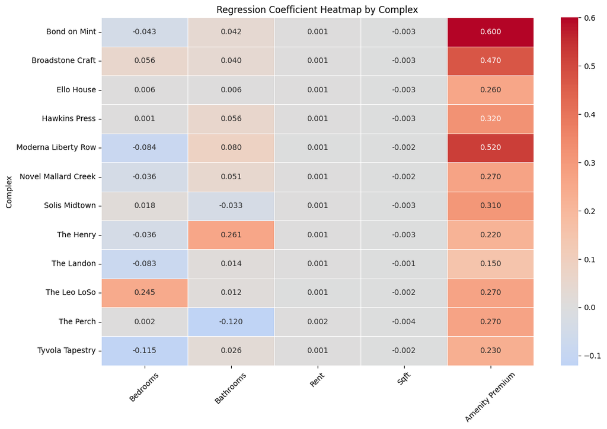

```python
# Create the data
data = {
    'Complex': [
        'Bond on Mint', 'Broadstone Craft', 'Ello House', 'Hawkins Press',
        'Moderna Liberty Row', 'Novel Mallard Creek', 'Solis Midtown',
        'The Henry', 'The Landon', 'The Leo LoSo', 'The Perch', 'Tyvola Tapestry'
    ],
    'Bedrooms': [
        -0.0425, 0.0564, 0.0056, 0.0012, -0.0841, -0.0357, 0.0182,
        -0.0365, -0.0832, 0.2451, 0.0016, -0.1154
    ],
    'Bathrooms': [
        0.0415, 0.0401, 0.0056, 0.0562, 0.0798, 0.0510, -0.0333,
        0.2611, 0.0142, 0.0120, -0.1200, 0.0260
    ],
    'Rent': [
        0.0010, 0.0012, 0.0013, 0.0012, 0.0008, 0.0011, 0.0010,
        0.0011, 0.0011, 0.0007, 0.0023, 0.0013
    ],
    'Sqft': [
        -0.0030, -0.0030, -0.0031, -0.0034, -0.0017, -0.0024, -0.0027,
        -0.0025, -0.0012, -0.0022, -0.0039, -0.0021
    ],
    'Amenity Premium': [
        0.60, 0.47, 0.26, 0.32, 0.52, 0.27, 0.31,
        0.22, 0.15, 0.27, 0.27, 0.23
    ]
}

# Convert to DataFrame
df = pd.DataFrame(data)
df.set_index('Complex', inplace=True)

# Create the heatmap
plt.figure(figsize=(12, 8))
sns.heatmap(df, annot=True, cmap='coolwarm', center=0, linewidths=0.5, fmt=".3f")
plt.title('Regression Coefficient Heatmap by Complex')
plt.xticks(rotation=45)
plt.tight_layout()
plt.show()
```

The regression coefficient heatmap offers a comparative view of how Charlotte’s apartment complexes structure their pricing logic across five key variables: bedrooms, bathrooms, rent, square footage, and amenity premiums. Each complex traces a distinct pricing fingerprint, revealing both shared patterns and strategic divergences.

Rent and square footage coefficients are consistent across all twelve complexes. Rent contributes positively to price per square foot, while square footage reduces it. This reinforces the citywide pattern of diminishing returns on space. These effects are stable and directional, anchoring each model in foundational pricing logic.

Bedroom and bathroom effects show the greatest variation. The Leo LoSo stands out with a strong positive bedroom coefficient (+0.245), indicating that additional bedrooms are priced as premium features. Tyvola Tapestry and Moderna Liberty Row show negative bedroom effects, suggesting layout dilution. The Henry assigns a substantial premium to bathrooms (+0.261), while The Perch penalizes them (−0.120), highlighting how layout features are valued differently across properties.

The heatmap’s color intensity reinforces these distinctions. Red tones signal strong positive effects, blue tones indicate negative impacts, and pale cells reflect minimal influence. This visual structure helps clarify which complexes rely most on layout, rent, or amenities, and which ones diverge from neighborhood norms.

In the broader context of your regression analysis, the heatmap validates the segmentation logic while surfacing the internal mechanics of each model. It supports stakeholder storytelling by making pricing logic intuitive and comparable, and it lays the groundwork for clustering, benchmarking, and deeper spatial interpretation.

## Complex Level Regressions Colclusion

The complex-level regressions offer a sharper lens into Charlotte’s rental pricing mechanics, revealing how individual properties structure value within, and sometimes in spite of, their neighborhood context. While neighborhood models capture submarket trends, these complex-specific regressions expose the internal logic of pricing: which features are consistently rewarded, which are bundled, and which are largely ignored.

Across all twelve complexes, rent and square footage remain the most stable predictors. Their directional effects are remarkably consistent. Higher rent correlates with higher price per square foot, while larger units dilute it. This underscores a citywide pattern of diminishing returns on space. This foundational logic holds even as other variables fluctuate.

Amenity effects, by contrast, are highly standardized within each complex but vary in magnitude across them. Properties like Bond on Mint, Moderna Liberty Row, and Broadstone Craft assign premiums of $0.60, $0.52, and $0.47 per square foot, respectively, to bundled features like pools, EV charging, and shared Wi-Fi. Others, like The Landon or The Henry, apply more modest premiums, suggesting mid-tier positioning or less aggressive bundling strategies. In many cases, amenities are priced identically within a complex, reinforcing the idea that value is derived from the presence of a lifestyle package rather than any single feature.

Bedroom and bathroom effects are the most variable. Most complexes treat them as statistically insignificant, but a few, like The Leo LoSo and The Henry, assign meaningful premiums. This indicates that layout size can matter when paired with specific branding or unit scarcity. The Landon, by contrast, penalizes additional bedrooms, suggesting a pricing logic that favors compact efficiency over spaciousness.

The radar chart of regression coefficients reinforces these distinctions. Each complex traces a unique pricing fingerprint. Some emphasize rent, others layout, and others amenities. This diversity underscores the limits of neighborhood-level generalizations and the value of zooming in.

The regression coefficient heatmap further clarifies these patterns by visualizing the magnitude and direction of each feature’s impact across complexes. Red tones highlight strong positive effects, such as The Leo LoSo’s bedroom premium or Bond on Mint’s amenity bundle. Blue tones signal negative impacts, like Tyvola Tapestry’s bedroom penalty or The Perch’s bathroom discount. The heatmap’s structure makes it easy to compare pricing logic at a glance, revealing which complexes lean on layout, which prioritize rent, and which rely on lifestyle packaging. It also surfaces outliers, such as The Henry’s unusually high bathroom valuation or The Landon’s minimal amenity emphasis.

Ultimately, the complex-level regressions validate the broader segmentation strategy while revealing the architectural logic of pricing at the unit level. They clarify which features are monetized consistently, which are contextually contingent, and which are simply placeholders. For stakeholders, this granularity supports more precise valuation, sharper competitive benchmarking, and more nuanced investment strategy. Rather than flattening Charlotte’s rental landscape into neighborhood averages, these models elevate the role of the individual property, where pricing is not just a function of location but of design, density, and deliberate feature packaging. The heatmap and radar chart together transform these regressions from statistical artifacts into visual narratives, making pricing logic not just explainable but intuitive.

# Overall Conclusion

Charlotte’s rental pricing regressions reveal a structured and multi-dimensional market, where value is shaped by the interplay of unit traits, amenity density, geographic desirability, and property-level nuance. Across all models, from citywide to bedroom, neighborhood, and complex levels, the analysis demonstrates strong statistical performance and a coherent pricing logic that reflects both broad trends and localized variation.

At the citywide level, the model explains over 95 percent of the variation in price per square foot, confirming that rent, square footage, and amenities are foundational drivers. Smaller units command higher PPSF due to layout efficiency and concentrated demand, while features like laundry, EV charging, and secure access consistently add value. Location effects are stable, with neighborhoods such as Uptown, SouthPark, and South End carrying premiums, and standout complexes like Bond on Mint and Moderna Liberty Row reinforcing brand-driven pricing.

Bedroom-level regressions add clarity around how pricing logic shifts with unit size. Studios and 1-bedrooms are highly sensitive to layout and amenity density, while 2- and 3-bedrooms reflect more selective valuation patterns. Bathrooms, for example, lose significance in larger units, and some amenities taper off as expectations shift with scale. These models reinforce the segmentation strategy and offer targeted insights for valuation and design.

Neighborhood-level regressions surface spatial dynamics that shape pricing beyond citywide averages. While core predictors remain stable, amenity effects and complex representation vary meaningfully by submarket. Uptown’s lower R², for instance, reflects a more diffuse pricing structure shaped by mixed-use development and fragmented branding. A Q-Q plot of residuals confirms the model’s statistical reliability and highlights the complexity of Uptown’s valuation logic, which responds to a broader set of contextual influences.

Complex-level regressions provide a close-up view of how individual properties structure value. Within each complex, pricing reflects a distinct logic. Some emphasize rent thresholds, others prioritize layout efficiency or bundled amenities. These models show that pricing is not just a function of location, but of design intent, branding, and the strategic packaging of features. Visual tools like the heatmap and radar chart translate these patterns into intuitive narratives, making pricing logic both accessible and actionable.

Together, these regressions form a cohesive analytical framework that balances statistical rigor with market insight. They validate the broader model while elevating the nuances, where price is shaped not just by averages, but by experience, efficiency, and place. For stakeholders, this layered understanding supports more precise valuation, strategic investment, and responsive policy design, ensuring that Charlotte’s rental landscape is interpreted not as a monolith, but as a mosaic of interlocking pricing strategies.

In sum, the results of these regressions confirm that Charlotte’s rental market operates with a high degree of internal logic. Pricing is not random or opaque, but instead reflects a consistent and interpretable structure across scales. From macro-level trends to micro-level distinctions, the models provide a reliable foundation for decision-making, empowering developers, investors, and policymakers to engage with the market on its own terms, with clarity, confidence, and precision.

Building on the strength of these regression models, the next section turns to decision trees. While regressions reveal the linear structure and statistical weight of individual predictors, decision trees offer a complementary lens that emphasizes interpretability, segmentation, and rule-based logic. By modeling how combinations of features interact to drive pricing outcomes, decision trees surface intuitive, branching pathways that mirror how stakeholders might actually evaluate units in practice. This approach is especially useful for identifying thresholds, nonlinear effects, and decision rules that govern pricing in more categorical or conditional terms. In the section that follows, we will explore how decision trees can distill Charlotte’s complex rental landscape into actionable, scenario-based insights.